# Predicting Past-Year Telehealth Use: NHIS 2024 Development and 2025 Temporal Validation

Team 1: CHERY Lab (prediction analysis: Yao Yao)

2026-11-20

```r
# Results were produced with these versions; other versions (especially
# xgboost >= 2.0) may give slightly different numbers.
print(sapply(c("xgboost", "PRROC", "survey", "grpreg"),
             function(p) as.character(packageVersion(p))))
```

```
##   xgboost     PRROC    survey    grpreg
## "1.7.6.1"   "1.3.1"   "4.2.1"   "3.5.0"
```

```r
print(R.version.string)
```

```
## [1] "R version 4.3.3 (2024-02-29)"
```

# 1 Overview

**Outcome.** `VIRAPP12M_A`: had a video or phone appointment with a doctor or other health professional in the past 12 months (1 = Yes, 2 = No; 7/8/9 excluded).

**Design.** The analysis has two phases.

- **Development (2024 only).** The 2024 NHIS Sample Adult file is split 80/20 into training and test sets (stratified by outcome), with 5-fold cross-validation inside the training set. Data-based screening (item coverage), variable selection, tuning and model fitting use the training set only. The coding dictionary was drafted from NHIS conventions while viewing predictor distributions in the full 2024 file, but no outcome information. From the 2025 file, only the list of variable names is read, to restrict candidates to items fielded in both years. The 2024 test set is used only to evaluate models whose form was fixed beforehand.
- **Temporal validation (2025).** The fixed models are evaluated on the 2025 file, an independent cross-sectional sample of different respondents collected one year later. Variable availability and coding are checked before evaluation; the models are not refit or modified.

**Variable selection.**

1. *Rule-based screening* of every 2024 item: fielded in 2025; at least 90% of 2024 training respondents with a substantive answer; not a survey-administration field; not redundant with a retained item; worded the same way in both years; and not an item whose answer a telehealth visit in the reference period can produce (counseling that may be delivered by video or phone, online contact with a provider).
2. *Outcome-proxy diagnostic.* Items that a telehealth visit cannot produce but that may stand in for the outcome (in-person care use, online health activity, treatment, prevention, cost barriers, COVID-19 history) are added one at a time to the theory-based model on the training data. Items contributing more than the strongest theory-based predictor are excluded. Unflagged care-use and access items are kept aside as *borderline* items for a sensitivity analysis only, because they measure care seeking itself; unflagged COVID-19 history remains an ordinary candidate.
3. *Coding.* Screened items are coded with an explicit dictionary (valid codes, nonresponse codes, skip meaning, category grouping, reference level); theory-based items are coded in `prepare_nhis()`. Codes, labels, universes and question wording were checked against the 2024 and 2025 Sample Adult codebooks (`codebook_verification.csv`).
4. *Statistical selection* among all candidates, with no item forced in: bidirectional stepwise selection by BIC starting from the intercept-only model, with group lasso (every item penalized) as a cross-check and repeated half-sample selection to assess stability. The five covariates of the project dashboard’s association model (age, insurance, education, Internet access, self-rated health) are part of the theory-based set and are treated like every other candidate. Nested cross-validation evaluates the selection and fitting steps *given the screened candidate set*; screening, coding and the outcome-proxy diagnostic are done once beforehand and are not repeated inside folds.
5. *Two comparisons*, with a constant (prevalence-only) model as the lower reference. (a) Full theory-based (Andersen) model vs stepwise BIC within the same 22 items: can the theory-based set be simplified? (b) Theory-based models vs models built from the wider screened pool (stepwise BIC, group lasso, XGBoost): how much do more items and different methods add?

**Theory-based set.** Andersen’s behavioral model is a conceptual framework without a standard variable list. The 22 items are one operationalization: commonly used predisposing, enabling and need measures available in both NHIS years. It is not a validated standard set. Urban-rural classification, a common enabling factor, was missing from the initial specification by oversight and was added afterwards; because earlier analyses had already shown it to be a strong predictor, this addition was not made blind to the data.

**Primary model.** The main-effects stepwise BIC model was fixed as the primary model before any test-set or 2025 evaluation. It is a compromise between parsimony and predictive performance, not the best-predicting model: BIC does not directly optimize out-of-sample log loss, stepwise search finds a good model along its search path rather than a guaranteed optimum, and fewer items do not by themselves make a model easier to use in practice. More flexible models (group lasso, including its sparser 1-SE version, and gradient boosting) are reported for comparison. Interaction and borderline-item analyses are exploratory and do not change the primary model.

**Weights.** Models are fit unweighted as the baseline, and discrimination and accuracy are reported both unweighted (performance in the analysis sample) and survey-weighted (performance for the U.S. adult population represented by the complete-case sample). A sensitivity analysis refits the primary formula with survey weights. Bootstrap intervals resample primary sampling units within strata and apply to the *unweighted* metrics of the already-fitted models; they reflect the clustered sample but not uncertainty from model training or selection, and they are not a full design-based inference for weighted metrics. The 2025 weighted calibration gap uses a design-based (Taylor linearization) interval from the `survey` package.

Run time is roughly 1.5 to 2 hours (nested cross-validation and repeated selection dominate). Slow chunks are cached after the first knit, and parallel steps run on macOS and Linux.

# 2 Data preparation

## 2.1 Theory-based predictors

The same function prepares both survey years, so the 2025 validation data use the 2024 coding rules.

```r
raw_fields <- c(
  "VIRAPP12M_A", "AGEP_A", "NOTCOV_A", "PRIVATE_A", "EDUCP_A",
  "ACCSSINT_A", "PHSTAT_A", "SEX_A", "HISPALLP_A", "REGION", "MARITAL_A",
  "NATUSBORN_A", "EMPWRKLSW1_A", "POVRATTC_A", "HYPEV_A", "DIBEV_A",
  "ASEV_A", "COPDEV_A", "CANEV_A", "ARTHEV_A", "DEPEV_A", "ANXEV_A",
  "DISAB3_A", "WTFA_A", "PSTRAT", "PPSU"
)

# The five covariates of the project dashboard's association model; part of
# the theory-based set, with no special status in selection.
dashboard_predictors <- c("age", "insurance", "education", "internet", "health")
added_predictors <- c(
  "sex", "race_eth", "region", "marital", "us_born", "worked_last_week",
  "pov_ratio", "hypertension", "diabetes", "asthma", "copd", "cancer",
  "arthritis", "depression", "anxiety", "disability"
)
expanded_predictors <- c(dashboard_predictors, added_predictors)

# Yes (1) / No (2) items; refused, not ascertained, don't know -> NA.
yes_no <- function(x) {
  factor(x, levels = c(2, 1), labels = c("No", "Yes"))
}

# Items with >= 1% "not ascertained" keep an explicit Unknown category.
with_unknown <- function(x, codes, labels) {
  out <- rep("Unknown", length(x))
  for (i in seq_along(codes)) out[x %in% codes[i]] <- labels[i]
  factor(out, levels = c(labels, "Unknown"))
}

prepare_nhis <- function(raw) {
  stopifnot(all(raw_fields %in% names(raw)))
  rows <- which(raw$VIRAPP12M_A %in% c(1, 2))
  d <- raw[rows, ]

  insurance <- rep(NA_character_, nrow(d))
  insured <- d$NOTCOV_A %in% 2
  insurance[d$NOTCOV_A %in% 1] <- "Uninsured"
  insurance[insured & d$PRIVATE_A %in% c(1, 2)] <- "Any private coverage"
  insurance[insured & d$PRIVATE_A %in% 3] <- "Public / other, no private"

  education <- rep(NA_character_, nrow(d))
  education[d$EDUCP_A %in% 0:2] <- "Less than high school"
  education[d$EDUCP_A %in% 3:4] <- "High school / GED"
  education[d$EDUCP_A %in% 5:7] <- "Some college / associate"
  education[d$EDUCP_A %in% 8:10] <- "Bachelor's or higher"

  race_eth <- rep(NA_character_, nrow(d))
  race_eth[d$HISPALLP_A %in% 1] <- "Hispanic"
  race_eth[d$HISPALLP_A %in% 2] <- "NH White"
  race_eth[d$HISPALLP_A %in% 3] <- "NH Black"
  race_eth[d$HISPALLP_A %in% 4] <- "NH Asian"
  race_eth[d$HISPALLP_A %in% 5:7] <- "NH other / multiple"

  data.frame(
    telehealth = as.integer(d$VIRAPP12M_A == 1),
    # AGEP_A 85 = 85 or older (top-coded); 97/98/99 -> NA.
    age = ifelse(d$AGEP_A %in% 18:85, d$AGEP_A, NA_integer_),
    insurance = factor(insurance, levels = c(
      "Any private coverage", "Public / other, no private", "Uninsured"
    )),
    education = factor(education, levels = c(
      "Bachelor's or higher", "Some college / associate",
      "High school / GED", "Less than high school"
    )),
    internet = factor(d$ACCSSINT_A, levels = c(1, 2),
                      labels = c("Internet access", "No internet access")),
    health = factor(d$PHSTAT_A, levels = 1:5,
                    labels = c("Excellent", "Very good", "Good", "Fair", "Poor")),
    sex = factor(d$SEX_A, levels = 1:2, labels = c("Male", "Female")),
    race_eth = factor(race_eth, levels = c(
      "NH White", "Hispanic", "NH Black", "NH Asian", "NH other / multiple"
    )),
    region = factor(d$REGION, levels = 1:4,
                    labels = c("Northeast", "Midwest", "South", "West")),
    marital = with_unknown(d$MARITAL_A, 1:3,
                           c("Married", "Living with partner", "Neither")),
    us_born = with_unknown(d$NATUSBORN_A, 1:2, c("Yes", "No")),
    # Edited recode (accounts for temporary absence and unpaid family work);
    # code 9 (don't know) becomes the Unknown category.
    worked_last_week = with_unknown(d$EMPWRKLSW1_A, 1:2, c("Yes", "No")),
    # 2024 top-codes the ratio at 11; apply the same cap to every year.
    pov_ratio = pmin(d$POVRATTC_A, 11),
    hypertension = yes_no(d$HYPEV_A),
    diabetes = yes_no(d$DIBEV_A),
    asthma = yes_no(d$ASEV_A),
    copd = yes_no(d$COPDEV_A),
    cancer = yes_no(d$CANEV_A),
    arthritis = yes_no(d$ARTHEV_A),
    depression = yes_no(d$DEPEV_A),
    anxiety = yes_no(d$ANXEV_A),
    disability = yes_no(d$DISAB3_A),
    survey_weight = d$WTFA_A,
    survey_stratum = d$PSTRAT,
    survey_psu = d$PPSU,
    source_row = rows
  )
}
```

## 2.2 Item labels, screening rules and coding dictionary

Item labels and the coding dictionary were written from NHIS conventions and then checked item by item against the 2024 and 2025 Sample Adult codebooks (codes, labels, universes, question wording; page references in `codebook_verification.csv`). The dictionary is exported to `coding_dictionary.csv`. For theory-based items, the dictionary documents the codes used for screening coverage; their analysis coding is done in `prepare_nhis()`.

```r
# Item labels, screening rules and the coding dictionary for the NHIS
# telehealth prediction analysis.
#
# The coding dictionary below was written from NHIS conventions and the
# codes observed in the 2024 file. Entries marked "verify" in particular
# must be checked against the 2024 and 2025 Sample Adult codebooks; the
# dictionary is exported to coding_dictionary.csv for that review.

variable_labels <- c(
  # Theory-based set: 21 items coded in prepare_nhis(), plus URBRRL23
  AGEP_A = "Age (top-coded 85)", NOTCOV_A = "Not covered by health insurance",
  PRIVATE_A = "Private insurance", EDUCP_A = "Education",
  ACCSSINT_A = "Uses the Internet", PHSTAT_A = "Self-rated health",
  SEX_A = "Sex", HISPALLP_A = "Race/ethnicity (single and multiple race)",
  REGION = "Census region", MARITAL_A = "Marital status (3 groups)",
  NATUSBORN_A = "Born in the United States",
  EMPWRKLSW1_A = "Worked last week (edited recode)",
  POVRATTC_A = "Family income-to-poverty ratio", HYPEV_A = "Ever hypertension",
  DIBEV_A = "Ever diabetes", ASEV_A = "Ever asthma", COPDEV_A = "Ever COPD",
  CANEV_A = "Ever cancer", ARTHEV_A = "Ever arthritis",
  DEPEV_A = "Ever depression", ANXEV_A = "Ever anxiety disorder",
  DISAB3_A = "Disability status (Washington Group)",
  # New candidates: predisposing
  CITZNSTP_A = "U.S. citizen", LEGMSTAT_A = "Legal marital status (5 groups)",
  LANGHM_A = "Language other than English spoken at home",
  AFVET_A = "Ever served on active duty (military)", ORIENT_A = "Sexual orientation",
  SCHCURENR_A = "Currently enrolled in school", PARSTAT_A = "Parental status",
  PCNTADLT_A = "Number of adults in family", PCNTKIDS_A = "Number of children in family",
  # New candidates: enabling / socioeconomic
  URBRRL23 = "Urban-rural classification (2023 scheme)",
  MAXEDUCP_A = "Highest education of any adult in family",
  HOUTENURE_A = "Home owned or rented", HOUYRSLIV_A = "Years at current address",
  FSNAP12M_A = "Received SNAP, past 12 months",
  INCWRKO_A = "Income from wages/self-employment", INCINTER_A = "Interest/dividend income",
  INCSSRR_A = "Social Security/Railroad Retirement income",
  INCSSISSDI_A = "SSI/SSDI income", INCWELF_A = "Public assistance income",
  INCRETIRE_A = "Retirement/pension income", INCOTHR_A = "Other income",
  CEVOTELC_A = "Voted in last local election", CEMMETNG_A = "Attended public meeting",
  CEVOLUN1_A = "Volunteered", ACCSSHOM_A = "Uses the Internet at home",
  # New candidates: insurance detail
  MEDICARE_A = "Medicare", MEDICAID_A = "Medicaid", MILITARY_A = "Military coverage",
  CHIP_A = "CHIP", OTHPUB_A = "State-sponsored health plan",
  OTHGOV_A = "Other government coverage", IHS_A = "Indian Health Service",
  HINOTYR_A = "Uninsured at any time, past 12 months",
  SINCOVRX_A = "Single-service plan: prescriptions",
  SINCOVVS_A = "Single-service plan: vision", SINCOVDE_A = "Single-service plan: dental",
  # New candidates: health behaviours
  SMKCIGST_A = "Cigarette smoking status", SMKECIGST_A = "E-cigarette use status",
  CIGAREV_A = "Ever smoked cigars", SMOKELSEV1_A = "Ever used smokeless tobacco",
  BMICAT_A = "BMI category",
  # New candidates: health conditions
  DEMENEV_A = "Ever dementia", PREDIB_A = "Ever prediabetes", STREV_A = "Ever stroke",
  MIEV_A = "Ever heart attack", ANGEV_A = "Ever angina",
  CHDEV_A = "Ever coronary heart disease", CHLEV_A = "Ever high cholesterol",
  EVERCOVD_A = "Ever had COVID-19",
  # New candidates: mental health and social wellbeing
  DEPFREQ_A = "Frequency of depressed feelings",
  ANXFREQ_A = "Frequency of worried/anxious feelings",
  LONELY_A = "Loneliness", SUPPORT_A = "Social/emotional support",
  LSATIS4_A = "Life satisfaction",
  # New candidates: functioning
  ANYDIFF_A = "Any functional difficulty", SOCWRKLIM_A = "Work limitation",
  SOCSCLPAR_A = "Difficulty participating in social activities",
  SOCERRNDS_A = "Difficulty doing errands alone",
  UPPOBJCT_A = "Difficulty grasping small objects", UPPRAISE_A = "Difficulty raising arms",
  UPPSLFCR_A = "Difficulty with self-care", COGMEMDFF_A = "Difficulty remembering",
  COMDIFF_A = "Difficulty communicating", EQUIP_A = "Uses mobility equipment",
  DIFF_A = "Difficulty walking/climbing steps", HEARINGDF_A = "Hearing difficulty",
  HEARAID_A = "Uses hearing aid", VISIONDF_A = "Vision difficulty",
  WEARGLSS_A = "Wears glasses", STEPS_A = "Difficulty climbing 12 steps",
  WLK100_A = "Difficulty walking 100 yards",
  # Items whose relation to the outcome is uncertain (checked by the
  # outcome-proxy diagnostic): access, treatment, prevention, cost barriers,
  # online health information and in-person care use
  MEDNG12M_A = "Did not get needed care due to cost, past 12 months",
  MEDDL12M_A = "Delayed care due to cost, past 12 months",
  PAYWORRY_A = "Worried about paying medical bills",
  PAYBLL12M_A = "Problems paying medical bills, past 12 months",
  MHTHND_A = "Needed mental health counseling but did not get it",
  MHTHDLY_A = "Delayed mental health counseling due to cost",
  HITLOOK_A = "Looked up health information online",
  USUALPL_A = "Has usual place of care", USPLKIND_A = "Type of usual place of care",
  RX12M_A = "Took prescription medication, past 12 months",
  RXDG12M_A = "Needed prescription medication but did not get it due to cost",
  DEPMED_A = "Takes medication for depression", ANXMED_A = "Takes medication for anxiety",
  SHTFLU12M_A = "Flu vaccine, past 12 months", SHTPNUEV_A = "Ever had pneumonia vaccine",
  # In-person care use (also checked by the diagnostic) and items whose
  # answer a telehealth visit can produce (excluded)
  RETAILHC12MTC_A = "Retail clinic visits, past 12 months",
  URGCC12MTC_A = "Urgent care visits, past 12 months",
  EMERG12MTC_A = "Emergency room visits, past 12 months",
  HOSPONGT_A = "Overnight hospital stay, past 12 months",
  MHTHRPY_A = "Received counseling from mental health professional, past 12 months",
  MHRX_A = "Took medication for mental health",
  HITTEST_A = "Viewed test results online", HITCOMM_A = "Communicated with provider online",
  WELLNESS_A = "Wellness visit, past 12 months", LASTDR_A = "Time since last doctor visit",
  # Excluded: redundant with a retained variable
  RATCAT_A = "Income-to-poverty ratio category", RACEALLP_A = "Race (single and multiple)",
  HISP_A = "Hispanic origin", HISDETP_A = "Hispanic origin detail",
  BMICATD_A = "BMI category (detailed)", WEIGHTLBTC_A = "Weight (lb)",
  HEIGHTTC_A = "Height (in)", HICOV_A = "Any health insurance coverage",
  EMPLASTWK_A = "Worked for pay last week (unedited)", SMKEV_A = "Ever smoked 100 cigarettes",
  ECIGEV_A = "Ever used e-cigarettes", PCNT18UPTC = "Adults in household",
  PCNTLT18TC = "Children in household", SAPARENTSC_A = "Sample adult is parent of sample child",
  NUMCAN_A = "Number of cancer types", OVER65FLG_A = "Any family member aged 65+",
  MARSTAT_A = "Current marital status (detailed)", HHX = "Household identifier",
  # Excluded: survey administration or label not verified
  INCTCFLG_A = "Income top-code flag", IMPINCFLG_A = "Income imputation flag",
  PPSU = "Pseudo-PSU", PSTRAT = "Pseudo-stratum", PROXYFLAG_A = "Proxy interview flag",
  ASTATNEW = "Sample adult status", MLTFAMFLG_A = "Multiple-family household flag",
  WTFA_A = "Final sample adult weight", HHSTAT_A = "Household status",
  IMPNUM_A = "Imputation number", RECTYPE = "Record type", SRVY_YR = "Survey year",
  TBIHLSBMC_A = "Not verified", TBILCDCMG_A = "Not verified",
  PCNTADWFP1_A = "Not verified (family adults working, recode)",
  PCNTADWKP1_A = "Not verified (family adults working, recode)"
)
for (v in sprintf("HIKIND%02d_A", 1:10)) {
  variable_labels[v] <- "Insurance type indicator (recode of plan variables)"
}
```

```r
core_raw <- c("AGEP_A", "NOTCOV_A", "PRIVATE_A", "EDUCP_A", "ACCSSINT_A", "PHSTAT_A")
# Theory-based items coded by the dictionary rather than prepare_nhis().
theory_dictionary_raw <- c("URBRRL23")
added16_raw <- c("SEX_A", "HISPALLP_A", "REGION", "MARITAL_A", "NATUSBORN_A",
                 "EMPWRKLSW1_A", "POVRATTC_A", "HYPEV_A", "DIBEV_A", "ASEV_A",
                 "COPDEV_A", "CANEV_A", "ARTHEV_A", "DEPEV_A", "ANXEV_A", "DISAB3_A")

# Items related to health care fall into three groups.
# 1. Leakage by definition (excluded): the answer can be produced by a
#    telehealth visit in the reference period (counseling that may be
#    delivered by video or phone, online contact with a provider).
leakage_raw <- c("MHTHRPY_A", "MHRX_A", "HITCOMM_A")
# 2. Not comparable across years (excluded): urgent-care visits were
#    reworded in 2025 to include drug-store and grocery clinics.
not_comparable_raw <- c("URGCC12MTC_A")
# 3. Uncertain: a telehealth visit does not produce the answer, but the item
#    may act as a proxy for the outcome (in-person care use, online health
#    activity, treatment, prevention, cost barriers, COVID-19 history).
#    These items go through the outcome-proxy diagnostic on the training
#    data. Flagged items are excluded. Unflagged EVERCOVD_A stays an ordinary
#    candidate; the other unflagged items describe care use or access and
#    are used only in a sensitivity analysis.
uncertain_raw <- c("EVERCOVD_A", "LASTDR_A", "WELLNESS_A", "RETAILHC12MTC_A",
                   "EMERG12MTC_A", "HOSPONGT_A", "HITTEST_A", "HITLOOK_A",
                   "RX12M_A", "RXDG12M_A", "DEPMED_A", "ANXMED_A", "USUALPL_A",
                   "SHTFLU12M_A", "SHTPNUEV_A", "MEDNG12M_A", "MEDDL12M_A",
                   "PAYWORRY_A", "PAYBLL12M_A", "MHTHND_A", "MHTHDLY_A")
uncertain_candidate_raw <- c("EVERCOVD_A")
redundant_raw <- c("RATCAT_A", "RACEALLP_A", "HISP_A", "HISDETP_A", "BMICATD_A",
                   "WEIGHTLBTC_A", "HEIGHTTC_A", "HICOV_A", sprintf("HIKIND%02d_A", 1:10),
                   "EMPLASTWK_A", "SMKEV_A", "ECIGEV_A", "PCNT18UPTC", "PCNTLT18TC",
                   "SAPARENTSC_A", "NUMCAN_A", "OVER65FLG_A", "MARSTAT_A",
                   # Follow-up items skipped for part of the sample, whose
                   # skip category would duplicate the parent item
                   "STEPS_A", "WLK100_A", "USPLKIND_A")
admin_raw <- c("HHX", "INCTCFLG_A", "IMPINCFLG_A", "PPSU", "PSTRAT", "PROXYFLAG_A",
               "HHSTAT_A", "IMPNUM_A", "RECTYPE", "SRVY_YR",
               "ASTATNEW", "MLTFAMFLG_A", "WTFA_A")
unverified_raw <- c("TBIHLSBMC_A", "TBILCDCMG_A", "PCNTADWFP1_A", "PCNTADWKP1_A")
too_rare_raw <- c("CHIP_A")  # 3 "yes" answers among 2024 respondents

# ---- Coding dictionary --------------------------------------------------------
# Each entry lists the analysis categories ("groups") and the NHIS codes in
# each, the codes treated as nonresponse (refused, not ascertained, don't
# know), the meaning of a blank (NA) when the item was skipped by design,
# how nonresponse is handled, and the reference category. Nonresponse gets
# its own "Missing" category when it is about 1% or more of 2024
# respondents; otherwise it is assigned to the most common category.
item <- function(groups, missing = c(7, 8, 9), skip = NULL,
                 nonresponse = "Missing", ref = names(groups)[1],
                 type = "categorical", note = "") {
  stopifnot(ref %in% names(groups),
            nonresponse %in% c("Missing", "Exclude", names(groups)))
  list(groups = groups, missing = missing, skip = skip,
       nonresponse = nonresponse, ref = ref, type = type, note = note)
}
yes_no_item <- function(nonresponse = "No", ref = "No", yes = 1, no = 2, ...) {
  item(setNames(list(yes, no), c("Yes", "No")), nonresponse = nonresponse,
       ref = ref, type = "binary", ...)
}
difficulty_item <- function(merge_cannot = FALSE, ...) {
  groups <- if (merge_cannot) {
    list("No difficulty" = 1, "Some difficulty" = 2,
         "A lot of difficulty or cannot do" = 3:4)
  } else {
    list("No difficulty" = 1, "Some difficulty" = 2,
         "A lot of difficulty" = 3, "Cannot do at all" = 4)
  }
  item(groups, nonresponse = "No difficulty", type = "ordinal", ...)
}
frequency_item <- function(...) {
  item(list("Never" = 5, "Daily" = 1, "Weekly" = 2, "Monthly" = 3,
            "A few times a year" = 4), type = "ordinal", ...)
}

coding_dictionary <- list(
  # Theory-based items: the analysis coding is done in
  # prepare_nhis(); these entries document the same rules (categories,
  # reference level, nonresponse handling) and supply the codes used for
  # screening coverage. "Exclude" = nonresponse becomes NA and the
  # respondent leaves the complete-case sample.
  AGEP_A = item(list("Age 18-85" = 18:85), missing = 97:99, type = "continuous",
                nonresponse = "Exclude", note = "85 = 85 or older"),
  NOTCOV_A = item(list("Not covered" = 1, "Covered" = 2), nonresponse = "Exclude",
                  note = "combined with PRIVATE_A into insurance in prepare_nhis()"),
  PRIVATE_A = item(list("Yes" = 1:2, "No" = 3), nonresponse = "Exclude",
                   note = "combined with NOTCOV_A into insurance in prepare_nhis()"),
  EDUCP_A = item(list("Bachelor's or higher" = 8:10, "Less than high school" = 0:2,
                      "High school / GED" = 3:4, "Some college / associate" = 5:7),
                 missing = 97:99, nonresponse = "Exclude"),
  ACCSSINT_A = yes_no_item(ref = "Yes", nonresponse = "Exclude"),
  PHSTAT_A = item(list("Excellent" = 1, "Very good" = 2, "Good" = 3,
                       "Fair" = 4, "Poor" = 5), type = "ordinal",
                  nonresponse = "Exclude"),
  SEX_A = item(list("Male" = 1, "Female" = 2), nonresponse = "Exclude"),
  HISPALLP_A = item(list("NH White" = 2, "Hispanic" = 1, "NH Black" = 3,
                         "NH Asian" = 4, "NH other / multiple" = 5:7),
                    missing = 97:99, nonresponse = "Exclude",
                    note = "7 = other single and multiple races (valid)"),
  REGION = item(list("Northeast" = 1, "Midwest" = 2, "South" = 3, "West" = 4),
                missing = numeric(0), nonresponse = "Exclude"),
  MARITAL_A = item(list("Married" = 1, "Living with partner" = 2, "Neither" = 3),
                   note = "nonresponse is the category Unknown in prepare_nhis()"),
  NATUSBORN_A = yes_no_item(ref = "Yes", nonresponse = "Missing",
                            note = "nonresponse is the category Unknown in prepare_nhis()"),
  EMPWRKLSW1_A = yes_no_item(ref = "Yes", nonresponse = "Missing",
                             note = "edited recode; 9 = don't know; nonresponse is the category Unknown in prepare_nhis()"),
  POVRATTC_A = item(list("Ratio 0-11" = 0:11), missing = numeric(0), type = "continuous",
                    nonresponse = "Exclude",
                    note = "continuous; top-coded at 11 in 2024, capped at 11"),
  HYPEV_A = yes_no_item(nonresponse = "Exclude"),
  DIBEV_A = yes_no_item(nonresponse = "Exclude"),
  ASEV_A = yes_no_item(nonresponse = "Exclude"),
  COPDEV_A = yes_no_item(nonresponse = "Exclude"),
  CANEV_A = yes_no_item(nonresponse = "Exclude"),
  ARTHEV_A = yes_no_item(nonresponse = "Exclude"),
  DEPEV_A = yes_no_item(nonresponse = "Exclude"),
  ANXEV_A = yes_no_item(nonresponse = "Exclude"),
  DISAB3_A = yes_no_item(nonresponse = "Exclude"),
```

```r
  # Predisposing
  CITZNSTP_A = yes_no_item(nonresponse = "Missing", ref = "Yes"),
  LEGMSTAT_A = item(list("Married" = 3, "Separated" = 1, "Divorced" = 2,
                         "Never married" = 4, "Widowed" = 5),
                    note = "9 = unknown legal marital status"),
  LANGHM_A = yes_no_item(nonresponse = "Missing"),
  AFVET_A = yes_no_item(nonresponse = "Missing"),
  ORIENT_A = item(list("Straight" = 2, "Gay or lesbian" = 1, "Bisexual" = 3,
                       "Something else" = 4, "Don't know the answer" = 5),
                  note = "5 = 'I don't know the answer', a listed response option"),
  SCHCURENR_A = yes_no_item(nonresponse = "Missing"),
  PARSTAT_A = item(list("No minor children in family" = 3,
                        "Parent of a child in family" = 1,
                        "Minor children in family, not their parent" = 2),
                   nonresponse = "No minor children in family",
                   note = "9 = unknown"),
  PCNTADLT_A = item(list("1" = 1, "2" = 2, "3 or more" = 3), missing = 8,
                    nonresponse = "2", type = "count"),
  PCNTKIDS_A = item(list("0" = 0, "1" = 1, "2" = 2, "3 or more" = 3),
                    missing = 8, nonresponse = "0", type = "count"),

  # Enabling / socioeconomic
  URBRRL23 = item(list("Large central metro" = 1, "Large fringe metro" = 2,
                       "Medium or small metro" = 3, "Nonmetropolitan" = 4),
                  missing = numeric(0), nonresponse = "Large central metro",
                  type = "ordinal"),
  MAXEDUCP_A = item(list("Bachelor's or higher" = 8:10,
                         "Less than high school" = 0:2, "High school / GED" = 3:4,
                         "Some college / associate" = 5:7),
                    missing = 97:99, nonresponse = "Bachelor's or higher",
                    note = "grouped like EDUCP_A"),
  HOUTENURE_A = item(list("Owned or being bought" = 1, "Rented" = 2,
                          "Other arrangement" = 3)),
  HOUYRSLIV_A = item(list("Less than 1 year" = 1, "1-3 years" = 2, "4-10 years" = 3,
                          "11-20 years" = 4, "More than 20 years" = 5),
                     type = "ordinal"),
  FSNAP12M_A = yes_no_item(nonresponse = "Missing"),
  INCWRKO_A = yes_no_item(nonresponse = "Missing"),
  INCINTER_A = yes_no_item(nonresponse = "Missing"),
  INCSSRR_A = yes_no_item(nonresponse = "Missing"),
  INCSSISSDI_A = yes_no_item(nonresponse = "Missing"),
  INCWELF_A = yes_no_item(nonresponse = "Missing"),
  INCRETIRE_A = yes_no_item(nonresponse = "Missing"),
  INCOTHR_A = yes_no_item(nonresponse = "Missing"),
  CEVOTELC_A = yes_no_item(nonresponse = "Missing"),
  CEMMETNG_A = yes_no_item(nonresponse = "Missing"),
  CEVOLUN1_A = yes_no_item(nonresponse = "Missing"),
  # Asked only of Internet users; non-users are coded "No" (no Internet use
  # at home) so the item does not duplicate the Internet access variable.
  ACCSSHOM_A = yes_no_item(ref = "Yes", nonresponse = "Yes", skip = "No",
                           note = "blank = not an Internet user, coded No"),

  # Insurance detail
  MEDICARE_A = yes_no_item(yes = 1:2, no = 3, note = "2 = yes, no detail"),
  MEDICAID_A = yes_no_item(yes = 1:2, no = 3, note = "2 = yes, no detail"),
  MILITARY_A = yes_no_item(yes = 1:2, no = 3),
  OTHPUB_A = yes_no_item(yes = 1:2, no = 3),
  OTHGOV_A = yes_no_item(yes = 1:2, no = 3),
  IHS_A = yes_no_item(),
  # Asked only of the currently insured; the currently uninsured were, by
  # definition, uninsured at some time in the past 12 months.
  HINOTYR_A = yes_no_item(skip = "Yes",
                          note = "blank = currently uninsured, coded Yes"),
  SINCOVRX_A = yes_no_item(nonresponse = "Missing"),
  SINCOVVS_A = yes_no_item(nonresponse = "Missing"),
  SINCOVDE_A = yes_no_item(nonresponse = "Missing"),

  # Health behaviours
  SMKCIGST_A = item(list("Never" = 4, "Current" = 1:2, "Former" = 3),
                    missing = c(5, 7, 8, 9),
                    note = "5 = smoker, current status unknown; 9 = unknown if ever smoked"),
  SMKECIGST_A = item(list("Never" = 3, "Current" = 1, "Former" = 2),
                     missing = c(4, 7, 8, 9),
                     note = "4 = user, current status unknown; 9 = unknown if ever used"),
  CIGAREV_A = yes_no_item(nonresponse = "Missing"),
  SMOKELSEV1_A = yes_no_item(nonresponse = "Missing"),
  BMICAT_A = item(list("Healthy weight" = 2, "Underweight" = 1, "Overweight" = 3,
                       "Obese" = 4), type = "ordinal"),

  # Health conditions
  DEMENEV_A = yes_no_item(), PREDIB_A = yes_no_item(), STREV_A = yes_no_item(),
  MIEV_A = yes_no_item(), ANGEV_A = yes_no_item(), CHDEV_A = yes_no_item(),
  CHLEV_A = yes_no_item(), EVERCOVD_A = yes_no_item(nonresponse = "Yes"),

  # Mental health and social wellbeing
  DEPFREQ_A = frequency_item(), ANXFREQ_A = frequency_item(),
  LONELY_A = item(list("Never" = 5, "Always" = 1, "Usually" = 2, "Sometimes" = 3,
                       "Rarely" = 4), type = "ordinal"),
  SUPPORT_A = item(list("Always" = 1, "Usually" = 2, "Sometimes" = 3, "Rarely" = 4,
                        "Never" = 5), type = "ordinal"),
  LSATIS4_A = item(list("Very satisfied" = 1, "Satisfied" = 2, "Dissatisfied" = 3,
                        "Very dissatisfied" = 4), nonresponse = "Satisfied",
                   type = "ordinal"),

  # Functioning
  ANYDIFF_A = yes_no_item(),
  SOCWRKLIM_A = yes_no_item(),
  SOCSCLPAR_A = difficulty_item(), SOCERRNDS_A = difficulty_item(),
  UPPOBJCT_A = difficulty_item(merge_cannot = TRUE), UPPRAISE_A = difficulty_item(),
  UPPSLFCR_A = difficulty_item(), COGMEMDFF_A = difficulty_item(merge_cannot = TRUE),
  COMDIFF_A = difficulty_item(merge_cannot = TRUE), EQUIP_A = yes_no_item(),
  DIFF_A = difficulty_item(), HEARINGDF_A = difficulty_item(merge_cannot = TRUE),
  HEARAID_A = yes_no_item(), VISIONDF_A = difficulty_item(merge_cannot = TRUE),
  WEARGLSS_A = yes_no_item(ref = "Yes", nonresponse = "Yes"),
  STEPS_A = difficulty_item(skip = "Uses mobility equipment (not asked)"),
  WLK100_A = difficulty_item(skip = "Uses mobility equipment (not asked)"),
```

```r
  # Borderline
  MEDNG12M_A = yes_no_item(), MEDDL12M_A = yes_no_item(),
  PAYWORRY_A = item(list("Not at all worried" = 3, "Very worried" = 1,
                         "Somewhat worried" = 2),
                    nonresponse = "Not at all worried", type = "ordinal"),
  PAYBLL12M_A = yes_no_item(),
  MHTHND_A = yes_no_item(), MHTHDLY_A = yes_no_item(),
  HITLOOK_A = yes_no_item(nonresponse = "Yes", skip = "No",
                          note = "blank = not an Internet user, coded No"),
  USUALPL_A = item(list("Yes" = 1, "No" = 2, "More than one place" = 3),
                   nonresponse = "Yes"),
  USPLKIND_A = item(list("Doctor's office or health center" = 1,
                         "Urgent care or retail clinic" = 2,
                         "Hospital emergency room" = 3, "VA facility" = 4,
                         "Other place or no one place" = 5:6),
                    nonresponse = "Doctor's office or health center",
                    skip = "No usual place (not asked)"),
  RX12M_A = yes_no_item(ref = "Yes", nonresponse = "Yes"),
  # In-person care use and online test results (uncertain items)
  LASTDR_A = item(list("Within the past year" = 1, "1 to 2 years ago" = 2,
                       "2 to 5 years ago" = 3:4, "5 or more years ago or never" = c(0, 5, 6)),
                  nonresponse = "Within the past year", type = "ordinal",
                  note = "question excludes appointments by video or phone"),
  WELLNESS_A = yes_no_item(ref = "Yes", nonresponse = "Yes", skip = "No",
                           note = "refers to the last visit; blank = no doctor visit, coded No"),
  RETAILHC12MTC_A = item(list("0" = 0, "1" = 1, "2" = 2, "3 or more" = 3:5),
                         nonresponse = "0", type = "count", note = "5 = 5 or more"),
  EMERG12MTC_A = item(list("0" = 0, "1" = 1, "2" = 2, "3 or more" = 3:4),
                      nonresponse = "0", type = "count", note = "4 = 4 or more"),
  HOSPONGT_A = yes_no_item(),
  HITTEST_A = yes_no_item(ref = "Yes", nonresponse = "Yes", skip = "No",
                          note = "blank = not an Internet user, coded No"),
  RXDG12M_A = yes_no_item(),
  DEPMED_A = yes_no_item(), ANXMED_A = yes_no_item(),
  SHTFLU12M_A = yes_no_item(nonresponse = "Missing"),
  SHTPNUEV_A = yes_no_item(nonresponse = "Missing")
)

dictionary_codes <- function(entry) unlist(entry$groups, use.names = FALSE)

# Dictionary in long form, for review against the codebooks.
dictionary_table <- function() {
  do.call(rbind, lapply(names(coding_dictionary), function(v) {
    e <- coding_dictionary[[v]]
    data.frame(
      variable = v, label = unname(variable_labels[v]), type = e$type,
      category = names(e$groups),
      nhis_codes = vapply(e$groups, function(g) {
        if (length(g) > 4 && all(diff(g) == 1)) sprintf("%g-%g", min(g), max(g))
        else paste(g, collapse = ",")
      }, character(1)),
      reference = names(e$groups) == e$ref,
      nonresponse_codes = paste(e$missing, collapse = ","),
      nonresponse_handling = e$nonresponse,
      skip_meaning = if (is.null(e$skip)) "" else e$skip,
      note = e$note
    )
  }))
}

# Coverage: share of respondents with a substantive answer. Dictionary codes
# are used when available; other items fall back to NHIS reserve-code
# conventions (7/8/9, 97/98/99, ...), which is approximate.
reserve_codes <- function(x) {
  v <- x[!is.na(x)]
  if (!length(v)) return(numeric(0))
  d <- nchar(as.character(floor(max(v))))
  top <- 10^d - c(3, 2, 1)
  others <- setdiff(unique(v), top)
  if (length(others) && max(others) >= 10^d - 3) numeric(0) else top
}

item_coverage <- function(v, x) {
  e <- coding_dictionary[[v]]
  if (!is.null(e)) {
    if (e$type == "continuous") {
      g <- e$groups[[1]]
      return(mean(!is.na(x) & x >= min(g) & x <= max(g) & !(x %in% e$missing)))
    }
    return(mean(x %in% dictionary_codes(e)))
  }
  mean(!is.na(x) & !(x %in% reserve_codes(x)))
}

# Screening uses the 2024 data and only the *names* of the 2025 variables
# (which items were fielded in 2025). No 2025 values or outcomes are read.
screen_variables <- function(raw_2024, names_2025, min_coverage = 0.90) {
  outcome_24 <- raw_2024$VIRAPP12M_A %in% c(1, 2)
  vars <- setdiff(names(raw_2024), "VIRAPP12M_A")

  out <- do.call(rbind, lapply(vars, function(v) {
    x <- raw_2024[[v]][outcome_24]
    data.frame(
      variable = v,
      coverage_2024 = if (is.numeric(x)) round(item_coverage(v, x), 3) else NA_real_,
      coverage_basis = if (v %in% names(coding_dictionary)) "dictionary" else
        "reserve-code convention (approximate)",
      share_nonblank_2024 = round(mean(!is.na(x)), 3)
    )
  }))
  out$fielded_2025 <- out$variable %in% names_2025

  low_coverage <- is.na(out$coverage_2024) | out$coverage_2024 < min_coverage
  v <- out$variable

  # Rules are applied in this order and a later rule overrides an earlier
  # one, so the list runs from lowest to highest priority. Theory-based
  # items are kept regardless of coverage (their coverage is reported in the
  # Rmd); final decisions for uncertain items are set after the
  # outcome-proxy diagnostic.
  decision <- rep("Excluded: not reviewed", length(v))
  rules <- list(
    list(v %in% names(coding_dictionary), "Candidate: new"),
    list(v %in% setdiff(uncertain_raw, uncertain_candidate_raw),
         "Uncertain: outcome-proxy check"),
    list(low_coverage, "Excluded: 2024 coverage < 90% (skip pattern)"),
    list(v %in% unverified_raw, "Excluded: label not verified"),
    list(v %in% too_rare_raw, "Excluded: too few respondents in a category"),
    list(v %in% admin_raw, "Excluded: survey administration"),
    list(v %in% redundant_raw, "Excluded: redundant"),
    list(v %in% not_comparable_raw, "Excluded: wording changed in 2025"),
    list(v %in% leakage_raw, "Excluded: answer can come from a telehealth visit"),
    list(v %in% c(core_raw, added16_raw, theory_dictionary_raw),
         "Candidate: theory-based set"),
    list(!out$fielded_2025, "Excluded: not fielded in 2025")
  )
  for (rule in rules) decision[rule[[1]]] <- rule[[2]]
  out$decision <- decision
  out$label <- unname(ifelse(v %in% names(variable_labels), variable_labels[v], ""))
  out[order(out$decision, out$variable),
      c("variable", "label", "decision", "coverage_2024", "coverage_basis",
        "share_nonblank_2024", "fielded_2025")]
}
```

```r
# ---- Coding --------------------------------------------------------------------
# Apply the dictionary. The rules are fixed in advance and are not learned
# from the data, so the same coding applies inside every CV fold and in 2025.
code_item <- function(x, e, v = "", on_unknown = c("error", "warning")) {
  on_unknown <- match.arg(on_unknown)
  unknown <- !is.na(x) & !(x %in% c(dictionary_codes(e), e$missing))
  if (any(unknown)) {
    msg <- sprintf("%s: %d value(s) with codes not in the dictionary (%s)",
                   v, sum(unknown), paste(sort(unique(x[unknown])), collapse = ","))
    if (on_unknown == "error") stop(msg, call. = FALSE)
    warning(msg, call. = FALSE)
  }
  out <- rep(NA_character_, length(x))
  for (g in names(e$groups)) out[x %in% e$groups[[g]]] <- g
  # A skip label may name an existing category (the skip implies the
  # answer) or a separate "not asked" category.
  skipped <- is.na(x) & !is.null(e$skip)
  if (any(skipped)) out[skipped] <- e$skip
  out[is.na(out)] <- e$nonresponse
  levels <- unique(c(e$ref, setdiff(names(e$groups), e$ref), e$skip,
                     if (e$nonresponse == "Missing") "Missing"))
  factor(out, levels = levels)
}

code_items <- function(raw, vars, on_unknown = "error") {
  as.data.frame(lapply(setNames(vars, vars), function(v) {
    code_item(raw[[v]], coding_dictionary[[v]], v, on_unknown)
  }), stringsAsFactors = FALSE, check.names = FALSE)
}

# Every recode applied to a dataset: several NHIS codes combined into one
# category, nonresponse assigned to a category, and codes not in the
# dictionary (treated as nonresponse).
describe_recodes <- function(raw, vars) {
  do.call(rbind, lapply(vars, function(v) {
    e <- coding_dictionary[[v]]
    x <- raw[[v]]
    rows <- list()
    for (g in names(e$groups)) {
      codes <- e$groups[[g]]
      if (length(codes) > 1 && e$type != "continuous") {
        n <- vapply(codes, function(cd) sum(x %in% cd), integer(1))
        rows[[length(rows) + 1]] <- data.frame(
          variable = v, action = "combined", codes = paste(codes, collapse = ","),
          n = paste(n, collapse = "/"), coded_as = g)
      }
    }
    unknown <- !is.na(x) & !(x %in% c(dictionary_codes(e), e$missing))
    if (any(unknown)) {
      rows[[length(rows) + 1]] <- data.frame(
        variable = v, action = "code not in dictionary",
        codes = paste(sort(unique(x[unknown])), collapse = ","),
        n = as.character(sum(unknown)), coded_as = e$nonresponse)
    }
    coded_nonresp <- x %in% e$missing
    if (any(coded_nonresp)) {
      rows[[length(rows) + 1]] <- data.frame(
        variable = v, action = "nonresponse code",
        codes = paste(sort(unique(x[coded_nonresp])), collapse = ","),
        n = as.character(sum(coded_nonresp)), coded_as = e$nonresponse)
    }
    blank_no_rule <- is.na(x) & is.null(e$skip)
    if (any(blank_no_rule)) {
      rows[[length(rows) + 1]] <- data.frame(
        variable = v, action = "blank, no skip rule", codes = "blank",
        n = as.character(sum(blank_no_rule)), coded_as = e$nonresponse)
    }
    blank_skip <- is.na(x) & !is.null(e$skip)
    if (any(blank_skip)) {
      rows[[length(rows) + 1]] <- data.frame(
        variable = v, action = "blank, skip rule", codes = "blank",
        n = as.character(sum(blank_skip)), coded_as = e$skip)
    }
    do.call(rbind, rows)
  }))
}
```

## 2.3 2024 sample, missingness and split

```r
nhis_2024 <- read.csv("adult24.csv")
model_data <- prepare_nhis(nhis_2024)

print(c(raw_n = nrow(nhis_2024), valid_outcome_n = nrow(model_data)))
```

```
##           raw_n valid_outcome_n
##           32629           32324
```

```r
has_complete <- complete.cases(model_data[expanded_predictors])
sample_check <- table(
  sample = ifelse(has_complete, "Retained", "Excluded"),
  telehealth = model_data$telehealth
)
print(sample_check)
```

```
##           telehealth
## sample         0     1
##   Excluded   330   117
##   Retained 23701  8176
```

```r
print(round(100 * prop.table(sample_check, margin = 1), 1))
```

```
##           telehealth
## sample        0    1
##   Excluded 73.8 26.2
##   Retained 74.4 25.6
```

```r
analysis_data <- model_data[has_complete, ]
print(c(complete_case_n = nrow(analysis_data)))
```

```
## complete_case_n
##           31877
```

```r
set.seed(2026)
rows_by_outcome <- split(seq_len(nrow(analysis_data)), analysis_data$telehealth)
train_rows <- sort(unlist(lapply(rows_by_outcome, function(rows) {
  sample(rows, size = floor(0.80 * length(rows)))
}), use.names = FALSE))
train_data <- analysis_data[train_rows, ]
test_data <- analysis_data[-train_rows, ]

print(data.frame(
  dataset = c("Training", "Test"),
  n = c(nrow(train_data), nrow(test_data)),
  users = c(sum(train_data$telehealth), sum(test_data$telehealth)),
  use_pct = round(100 * c(mean(train_data$telehealth),
                          mean(test_data$telehealth)), 2)
))
```

```
##    dataset     n users use_pct
## 1 Training 25500  6540   25.65
## 2     Test  6377  1636   25.65
```

```r
# Stratified 5-fold CV assignment within the training set.
k <- 5L
set.seed(2026)
fold_id <- integer(nrow(train_data))
for (rows in split(seq_len(nrow(train_data)), train_data$telehealth)) {
  fold_id[sample(rows)] <- rep(seq_len(k), length.out = length(rows))
}
validation_folds <- lapply(seq_len(k), function(f) which(fold_id == f))
```

## 2.4 Screening result

Coverage is computed from the predictor values of the 2024 *training* respondents; the only 2025 information used is the list of variable names (whether an item was fielded in 2025). The screen never uses the outcome or any 2025 values. The full table is written to `variable_screening.csv`.

```r
# Header row only: the list of items fielded in 2025.
names_2025 <- names(read.csv("adult25.csv", nrows = 0))

screening <- screen_variables(nhis_2024[train_data$source_row, ], names_2025)
write.csv(dictionary_table(), "coding_dictionary.csv", row.names = FALSE)
print(as.data.frame(table(decision = screening$decision)), row.names = FALSE)
```

```
##                                           decision Freq
##                                     Candidate: new   67
##                        Candidate: theory-based set   23
##       Excluded: 2024 coverage < 90% (skip pattern)  263
##  Excluded: answer can come from a telehealth visit    3
##                       Excluded: label not verified    4
##                      Excluded: not fielded in 2025  204
##                                Excluded: redundant   30
##                    Excluded: survey administration   13
##        Excluded: too few respondents in a category    1
##                  Excluded: wording changed in 2025    1
##                     Uncertain: outcome-proxy check   20
```

```r
# Candidate items beyond the theory-based set, and uncertain items that go
# through the outcome-proxy diagnostic below. Every screened item, uncertain
# ones included, is coded so that the diagnostic can use it.
new_candidates <- screening$variable[screening$decision == "Candidate: new"]
uncertain_items <- screening$variable[
  screening$decision == "Uncertain: outcome-proxy check"
]
pool_items <- c(theory_dictionary_raw, new_candidates, uncertain_items)
stopifnot(all(pool_items %in% names(coding_dictionary)))
cat("New candidates:", length(new_candidates),
    "| uncertain items to check:", length(uncertain_items), "\n")
```

```
## New candidates: 67 | uncertain items to check: 20
```

```r
# Theory-based items are kept regardless of coverage; report any below the
# 90% threshold that applies to the other items.
theory_rows <- screening[screening$decision == "Candidate: theory-based set", ]
cat("Theory-based items with 2024 coverage < 90%:",
    if (any(theory_rows$coverage_2024 < 0.9)) {
      paste(theory_rows$variable[theory_rows$coverage_2024 < 0.9], collapse = ", ")
    } else "none", "\n")
```

```
## Theory-based items with 2024 coverage < 90%: none
```

```r
# Items whose coverage is not dictionary-based and whose blanks alone would
# not exclude them: their exclusion rests on the reserve-code convention.
approximate <- screening[screening$coverage_basis != "dictionary" &
                           screening$share_nonblank_2024 >= 0.9 &
                           screening$decision ==
                             "Excluded: 2024 coverage < 90% (skip pattern)", ]
cat("Exclusions resting on approximate coverage:",
    if (nrow(approximate)) paste(approximate$variable, collapse = ", ") else "none",
    "\n")
```

```
## Exclusions resting on approximate coverage: WLK13M_A
```

```r
add_pool <- function(data, raw, on_unknown = "error") {
  cbind(data, code_items(raw[data$source_row, ], pool_items, on_unknown))
}
train_data <- add_pool(train_data, nhis_2024)
test_data <- add_pool(test_data, nhis_2024)

# Smallest category of each item in the training data.
smallest <- sort(vapply(train_data[pool_items], function(f) min(table(f)),
                        integer(1)))
print(head(smallest, 8))
```

```
##    OTHGOV_A  UPPSLFCR_A       IHS_A    ORIENT_A    OTHPUB_A SHTFLU12M_A  UPPRAISE_A   COMDIFF_A
##          53          98         141         143         152         156         164         186
```

The coding is fixed by the dictionary rather than learned from the data, so it is identical inside every cross-validation fold and in 2025. Several NHIS codes are combined into one category where categories are small or equivalent (for example “cannot do at all” with “a lot of difficulty”; Medicare “yes, no detail” with “yes”). Nonresponse is handled per item as written in the dictionary: a separate “Missing” category when it is about 1% or more of respondents, otherwise assignment to the most common category. Blanks are interpreted as “not asked” only where the dictionary gives a skip rule; other blanks are counted as nonresponse and reported separately below. A code that the dictionary does not list stops the analysis in 2024 and triggers a warning in 2025. Every recode in the training data:

```r
print(describe_recodes(nhis_2024[train_data$source_row, ], pool_items),
      row.names = FALSE)
```

```
##         variable              action  codes              n                         coded_as
##       ACCSSHOM_A    nonresponse code    7,8              3                              Yes
##       ACCSSHOM_A    blank, skip rule  blank           1844                               No
##          AFVET_A    nonresponse code  7,8,9            742                          Missing
##          ANGEV_A    nonresponse code      9             28                               No
##        ANXFREQ_A    nonresponse code  7,8,9            223                          Missing
##         BMICAT_A    nonresponse code      9            437                          Missing
##       CEMMETNG_A    nonresponse code  7,8,9            911                          Missing
##       CEVOLUN1_A    nonresponse code  7,8,9            809                          Missing
##       CEVOTELC_A    nonresponse code  7,8,9            982                          Missing
##          CHDEV_A    nonresponse code    7,9             61                               No
##          CHLEV_A    nonresponse code    7,9             49                               No
##        CIGAREV_A    nonresponse code  7,8,9            367                          Missing
##       CITZNSTP_A    nonresponse code  7,8,9            782                          Missing
##      COGMEMDFF_A            combined    3,4         730/25 A lot of difficulty or cannot do
##      COGMEMDFF_A    nonresponse code      9              5                    No difficulty
##        COMDIFF_A            combined    3,4         152/34 A lot of difficulty or cannot do
##        COMDIFF_A    nonresponse code      9              6                    No difficulty
##        DEMENEV_A    nonresponse code      9              5                               No
##        DEPFREQ_A    nonresponse code  7,8,9            243                          Missing
##           DIFF_A    nonresponse code    7,9              7                    No difficulty
##       EVERCOVD_A    nonresponse code    7,9            125                              Yes
##       FSNAP12M_A    nonresponse code  7,8,9            909                          Missing
##      HEARINGDF_A            combined    3,4         439/20 A lot of difficulty or cannot do
##      HEARINGDF_A    nonresponse code      9              6                    No difficulty
##        HINOTYR_A    nonresponse code    7,9             15                               No
##        HINOTYR_A    blank, skip rule  blank           1716                              Yes
##      HOUTENURE_A    nonresponse code  7,8,9            872                          Missing
##      HOUYRSLIV_A    nonresponse code  7,8,9            925                          Missing
##            IHS_A    nonresponse code      9              1                               No
##       INCINTER_A    nonresponse code  7,8,9           1327                          Missing
##        INCOTHR_A    nonresponse code  7,8,9            152                          Missing
##        INCOTHR_A blank, no skip rule  blank            887                          Missing
##      INCRETIRE_A    nonresponse code  7,8,9            184                          Missing
##      INCRETIRE_A blank, no skip rule  blank            887                          Missing
##     INCSSISSDI_A    nonresponse code  7,8,9            201                          Missing
##     INCSSISSDI_A blank, no skip rule  blank            887                          Missing
##        INCSSRR_A    nonresponse code  7,8,9            171                          Missing
##        INCSSRR_A blank, no skip rule  blank            887                          Missing
##        INCWELF_A    nonresponse code  7,8,9            129                          Missing
```

[output cut: 55 more lines]

```
##       MEDDL12M_A    nonresponse code      9              8                               No
##       MEDNG12M_A    nonresponse code    7,9              7                               No
##        MHTHDLY_A    nonresponse code  7,8,9            194                               No
##         MHTHND_A    nonresponse code  7,8,9            194                               No
##      PAYBLL12M_A    nonresponse code  7,8,9             60                               No
##       PAYWORRY_A    nonresponse code    7,9             37               Not at all worried
##  RETAILHC12MTC_A            combined  3,4,5    418/213/351                        3 or more
##  RETAILHC12MTC_A    nonresponse code    7,9             34                                0
##          RX12M_A    nonresponse code  7,8,9             28                              Yes
##        RXDG12M_A    nonresponse code  7,8,9             25                               No
##      SHTFLU12M_A    nonresponse code  7,8,9            156                          Missing
##       SHTPNUEV_A    nonresponse code  7,8,9            758                          Missing
##        USUALPL_A    nonresponse code    7,9             18                              Yes
##       WELLNESS_A    nonresponse code      9             47                              Yes
##       WELLNESS_A    blank, skip rule  blank             78                               No
```

# 3 Model development (training set only)

## 3.1 Metrics

```r
log_loss <- function(y, p) {
  p <- pmin(pmax(p, 1e-15), 1 - 1e-15)
  -mean(y * log(p) + (1 - y) * log1p(-p))
}

# Mann-Whitney AUROC; tied scores receive average ranks.
auroc <- function(p, y) {
  n1 <- sum(y == 1)
  n0 <- sum(y == 0)
  (sum(rank(p)[y == 1]) - n1 * (n1 + 1) / 2) / (n1 * n0)
}

evaluate_prob <- function(prob, y) {
  auprc <- if (length(unique(prob)) == 1L) {
    mean(y)
  } else {
    pr.curve(scores.class0 = prob[y == 1],
             scores.class1 = prob[y == 0])$auc.integral
  }
  c(log_loss = log_loss(y, prob), AUROC = auroc(prob, y),
    AUPRC = auprc, Brier = mean((y - prob)^2))
}

# Calibration-in-the-large (intercept with slope fixed at 1) and slope.
calibration_stats <- function(prob, y) {
  lp <- qlogis(pmin(pmax(prob, 1e-6), 1 - 1e-6))
  c(
    mean_predicted = mean(prob),
    mean_observed = mean(y),
    cal_intercept = unname(coef(glm(y ~ offset(lp), family = binomial()))[1]),
    cal_slope = unname(coef(glm(y ~ lp, family = binomial()))[2])
  )
}

# Stop on non-convergence, aliased coefficients or non-finite predictions.
# A factor level absent from a fold's training part makes predict() stop
# with a "new levels" error, which is also surfaced rather than ignored.
check_fit <- function(fit, label) {
  if (!fit$converged) stop(label, ": glm did not converge", call. = FALSE)
  if (anyNA(coef(fit))) {
    stop(label, ": aliased coefficients ",
         paste(names(which(is.na(coef(fit)))), collapse = ", "), call. = FALSE)
  }
  invisible(fit)
}

cv_logistic <- function(formula) {
  vapply(seq_len(k), function(fold) {
    fit <- glm(formula, data = train_data[fold_id != fold, ],
               family = binomial())
    check_fit(fit, paste("fold", fold))
    valid <- train_data[fold_id == fold, ]
    p <- predict(fit, newdata = valid, type = "response")
    stopifnot(all(is.finite(p)))
    log_loss(valid$telehealth, p)
  }, numeric(1))
}
```

## 3.2 Candidate model formulas

```r
# The theory-based (Andersen) set: 22 items, including the five covariates
# used in the project dashboard's association model and urban-rural
# classification. None of them has a special status: in every selection
# procedure below they are candidates like any other item.
andersen_terms <- c("ns(age, df = 3)", "insurance", "education", "internet",
                    "health", setdiff(added_predictors, "pov_ratio"),
                    "ns(pov_ratio, df = 3)", theory_dictionary_raw)
f_null <- telehealth ~ 1
f_theory <- reformulate(andersen_terms, response = "telehealth")
```

## 3.3 Outcome-proxy diagnostic for uncertain items

Items that a telehealth visit cannot produce, but that may act as proxies for the outcome (in-person care use, online health activity, treatment, prevention, cost barriers, COVID-19 history), are checked on the training data. Each item is added to the theory-based model, and its contribution is compared with that of the strongest theory-based predictor:

- gain in 5-fold CV log loss when the item is added, against the largest increase in CV log loss when one theory-based item is removed;
- likelihood-ratio statistic per degree of freedom, against the largest such statistic among theory-based items.

An item that exceeds either benchmark contributes more than any accepted predictor and is excluded as a possible proxy for the outcome. Unflagged `EVERCOVD_A` remains an ordinary candidate; the other unflagged items describe care use or access and are used only in the borderline sensitivity analysis. The diagnostic uses training outcomes and is not repeated inside the nested cross-validation folds; it can show that an item is suspicious but cannot prove that it is safe.

```r
fit_terms <- function(terms_) {
  glm(reformulate(terms_, response = "telehealth"), data = train_data,
      family = binomial())
}
lr_per_df <- function(terms_full, term) {
  full <- fit_terms(terms_full)
  reduced <- fit_terms(setdiff(terms_full, term))
  (reduced$deviance - full$deviance) / (length(coef(full)) - length(coef(reduced)))
}

theory_cv <- mean(cv_logistic(f_theory))
benchmark <- data.frame(
  term = andersen_terms,
  cv_logloss_change = vapply(andersen_terms, function(t) {
    mean(cv_logistic(reformulate(setdiff(andersen_terms, t), response = "telehealth"))) -
      theory_cv
  }, numeric(1)),
  lr_per_df = vapply(andersen_terms, lr_per_df, numeric(1),
                     terms_full = andersen_terms)
)
gain_threshold <- max(benchmark$cv_logloss_change)
lr_threshold <- max(benchmark$lr_per_df)
cat("Benchmarks: CV log loss", round(gain_threshold, 5),
    "| LR per df", round(lr_threshold, 1), "\n")
```

```
## Benchmarks: CV log loss 0.00468 | LR per df 147
```

```r
check_items <- intersect(uncertain_raw, pool_items)
proxy_check <- data.frame(
  item = check_items,
  label = unname(variable_labels[check_items]),
  cv_logloss_gain = vapply(check_items, function(v) {
    theory_cv - mean(cv_logistic(reformulate(c(andersen_terms, v),
                                             response = "telehealth")))
  }, numeric(1)),
  lr_per_df = vapply(check_items, function(v) {
    lr_per_df(c(andersen_terms, v), v)
  }, numeric(1))
)
proxy_check$flagged <- proxy_check$cv_logloss_gain > gain_threshold |
  proxy_check$lr_per_df > lr_threshold
proxy_check <- proxy_check[order(-proxy_check$cv_logloss_gain), ]
print(transform(proxy_check, cv_logloss_gain = round(cv_logloss_gain, 5),
                lr_per_df = round(lr_per_df, 1)), row.names = FALSE)
```

```
##             item                                                         label cv_logloss_gain lr_per_df
##        HITTEST_A                                    Viewed test results online         0.02006    1022.0
##          RX12M_A                  Took prescription medication, past 12 months         0.01286     660.7
##        HITLOOK_A                           Looked up health information online         0.01001     510.6
##         LASTDR_A                                  Time since last doctor visit         0.00657     113.4
##     EMERG12MTC_A                         Emergency room visits, past 12 months         0.00270      49.2
##       HOSPONGT_A                       Overnight hospital stay, past 12 months         0.00207     108.5
##         ANXMED_A                                  Takes medication for anxiety         0.00185      94.8
##        USUALPL_A                                       Has usual place of care         0.00168      43.7
##       EVERCOVD_A                                             Ever had COVID-19         0.00155      83.2
##        RXDG12M_A Needed prescription medication but did not get it due to cost         0.00114      61.0
##      SHTFLU12M_A                                   Flu vaccine, past 12 months         0.00110      32.1
##        MHTHDLY_A                  Delayed mental health counseling due to cost         0.00094      47.5
##  RETAILHC12MTC_A                          Retail clinic visits, past 12 months         0.00072      16.5
##         DEPMED_A                               Takes medication for depression         0.00071      37.3
##       MEDDL12M_A                      Delayed care due to cost, past 12 months         0.00062      32.2
##       SHTPNUEV_A                                    Ever had pneumonia vaccine         0.00062      22.3
##         MHTHND_A            Needed mental health counseling but did not get it         0.00048      25.0
##       MEDNG12M_A           Did not get needed care due to cost, past 12 months         0.00041      24.2
##       WELLNESS_A                                Wellness visit, past 12 months         0.00041      23.7
##      PAYBLL12M_A                 Problems paying medical bills, past 12 months         0.00038      24.5
##       PAYWORRY_A                            Worried about paying medical bills         0.00009       6.3
##  flagged
##     TRUE
##     TRUE
##     TRUE
##     TRUE
##    FALSE
##    FALSE
##    FALSE
##    FALSE
##    FALSE
##    FALSE
##    FALSE
##    FALSE
##    FALSE
##    FALSE
##    FALSE
##    FALSE
##    FALSE
##    FALSE
##    FALSE
##    FALSE
##    FALSE
```

```r
flagged_items <- proxy_check$item[proxy_check$flagged]
passed_items <- proxy_check$item[!proxy_check$flagged]

new_candidates <- setdiff(new_candidates, flagged_items)
borderline_candidates <- setdiff(passed_items, uncertain_candidate_raw)

screening$decision[screening$variable %in% flagged_items] <-
  "Excluded: outcome-proxy diagnostic"
screening$decision[screening$variable %in% borderline_candidates] <-
  "Candidate: borderline (sensitivity only)"
write.csv(screening, "variable_screening.csv", row.names = FALSE)

cat("Excluded by the diagnostic:",
    if (length(flagged_items)) paste(flagged_items, collapse = ", ") else "none", "\n")
```

```
## Excluded by the diagnostic: HITTEST_A, RX12M_A, HITLOOK_A, LASTDR_A
```

```r
cat("Borderline (sensitivity only):", paste(borderline_candidates, collapse = ", "), "\n")
```

```
## Borderline (sensitivity only): EMERG12MTC_A, HOSPONGT_A, ANXMED_A, USUALPL_A, RXDG12M_A, SHTFLU12M_A, MHTHDLY_A, RETAILHC12MTC_A, DEPMED_A, MEDDL12M_A, SHTPNUEV_A, MHTHND_A, MEDNG12M_A, WELLNESS_A, PAYBLL12M_A, PAYWORRY_A
```

```r
# All candidates: the theory-based set plus the screened new items.
pool_terms <- c(andersen_terms, new_candidates)
f_pool <- reformulate(pool_terms, response = "telehealth")
cat("Candidate terms:", length(pool_terms), "\n")
```

```
## Candidate terms: 89
```

```r
# No candidate may be an exact linear combination of others (for example, a
# "not asked" category identical to a category of another item): the full
# pool, with and without borderline items, must have no aliased terms.
for (f in list(f_pool, update(f_pool, paste(". ~ . +",
                                             paste(borderline_candidates,
                                                   collapse = " + "))))) {
  aliased <- names(which(is.na(coef(glm(f, data = train_data, family = binomial())))))
  if (length(aliased)) stop("Aliased coefficients: ", paste(aliased, collapse = ", "))
}
```

## 3.4 Stepwise selection by BIC (primary)

Bidirectional stepwise search starting from the intercept-only model, with every candidate (theory-based items included) free to enter or leave. The BIC penalty is log(n) per parameter, with each item entering or leaving as a whole (all of its levels together). This main-effects model was fixed as the primary model before any evaluation, as a compromise between parsimony and predictive performance rather than as the best-predicting model. BIC does not directly optimize out-of-sample log loss, and the stepwise search returns a good model along its path, not a guaranteed global optimum.

```r
n_train <- nrow(train_data)
fit_null <- glm(f_null, data = train_data, family = binomial())
fit_bic <- step(fit_null, scope = list(lower = f_null, upper = f_pool),
                direction = "both", k = log(n_train), trace = 0)

bic_terms <- attr(terms(fit_bic), "term.labels")
f_bic <- reformulate(bic_terms, response = "telehealth")

cat("Selected", length(bic_terms), "terms:\n")
```

```
## Selected 23 terms:
```

```r
print(data.frame(
  order = seq_along(bic_terms),
  term = bic_terms,
  label = ifelse(bic_terms %in% names(variable_labels),
                 variable_labels[bic_terms], "(theory-based set)")
), row.names = FALSE)
```

```
##  order                  term                                    label
##      1            depression                       (theory-based set)
##      2             education                       (theory-based set)
##      3             ANXFREQ_A    Frequency of worried/anxious feelings
##      4                region                       (theory-based set)
##      5                health                       (theory-based set)
##      6              URBRRL23 Urban-rural classification (2023 scheme)
##      7             insurance                       (theory-based set)
##      8            EVERCOVD_A                        Ever had COVID-19
##      9               anxiety                       (theory-based set)
##     10            ACCSSHOM_A                Uses the Internet at home
##     11            CEVOTELC_A             Voted in last local election
##     12           SOCWRKLIM_A                          Work limitation
##     13                cancer                       (theory-based set)
##     14            MILITARY_A                        Military coverage
##     15                   sex                       (theory-based set)
##     16              PREDIB_A                         Ever prediabetes
##     17 ns(pov_ratio, df = 3)                       (theory-based set)
##     18                asthma                       (theory-based set)
##     19       ns(age, df = 3)                       (theory-based set)
##     20             arthritis                       (theory-based set)
##     21               EQUIP_A                  Uses mobility equipment
##     22               CHLEV_A                    Ever high cholesterol
##     23            CEMMETNG_A                  Attended public meeting
```

```r
# Were the five dashboard covariates selected without being forced in?
dashboard_terms <- c("ns(age, df = 3)", "insurance", "education", "internet", "health")
print(data.frame(term = dashboard_terms, selected = dashboard_terms %in% bic_terms),
      row.names = FALSE)
```

```
##             term selected
##  ns(age, df = 3)     TRUE
##        insurance     TRUE
##        education     TRUE
##         internet    FALSE
##           health     TRUE
```

## 3.5 Stepwise BIC within the theory-based items

The same search restricted to the 22 theory-based (Andersen) items. Compared with the full theory-based model, it shows whether that set can be simplified; compared with the primary model, it isolates the contribution of the wider candidate pool.

```r
fit_bic_theory <- step(fit_null, scope = list(lower = f_null, upper = f_theory),
                       direction = "both", k = log(n_train), trace = 0)
bic_theory_terms <- attr(terms(fit_bic_theory), "term.labels")
f_bic_theory <- reformulate(bic_theory_terms, response = "telehealth")

cat("Kept", length(bic_theory_terms), "of", length(andersen_terms),
    "theory-based terms:", paste(bic_theory_terms, collapse = ", "), "\n")
```

```
## Kept 17 of 22 theory-based terms: depression, education, health, anxiety, region, URBRRL23, insurance, internet, sex, ns(pov_ratio, df = 3), cancer, asthma, disability, ns(age, df = 3), arthritis, diabetes, us_born
```

```r
cat("Dropped:", paste(setdiff(andersen_terms, bic_theory_terms), collapse = ", "), "\n")
```

```
## Dropped: race_eth, marital, worked_last_week, hypertension, copd
```

## 3.6 Group lasso (cross-check)

Each item is one group (all of its dummy columns or spline bases), and every group is penalized. The penalty is tuned with the same 5 folds. Both the lambda.min fit and the sparser 1-SE fit are carried forward to the test-set and 2025 comparisons.

```r
# Build the design from a given set of rows. The terms object carries the
# spline knots of those rows ("predvars"), so any other data get the same
# basis.
build_design <- function(fit_data) {
  terms_object <- terms(model.frame(reformulate(pool_terms), data = fit_data))
  mm <- model.matrix(terms_object, model.frame(terms_object, data = fit_data))
  term_of_column <- attr(terms_object, "term.labels")[attr(mm, "assign")[-1]]
  group_id <- as.integer(factor(term_of_column, levels = unique(term_of_column)))
  list(
    x = mm[, -1, drop = FALSE], term_of_column = term_of_column,
    group_id = group_id,
    matrix_for = function(data) {
      model.matrix(terms_object, model.frame(terms_object, data = data))[, -1, drop = FALSE]
    }
  )
}

train_design <- build_design(train_data)
x_train <- train_design$x
term_of_column <- train_design$term_of_column
group_id <- train_design$group_id
design_matrix <- train_design$matrix_for

set.seed(2026)
cv_glasso <- cv.grpreg(x_train, train_data$telehealth, group = group_id,
                       penalty = "grLasso", family = "binomial",
                       fold = fold_id, nlambda = 60)

i_min <- which.min(cv_glasso$cve)
i_1se <- min(which(cv_glasso$cve <= cv_glasso$cve[i_min] + cv_glasso$cvse[i_min]))

selected_groups <- function(i) {
  b <- cv_glasso$fit$beta[-1, i]
  unique(term_of_column[b != 0])
}
glasso_min_terms <- selected_groups(i_min)
glasso_1se_terms <- selected_groups(i_1se)

print(data.frame(
  rule = c("lambda.min", "lambda.1se"),
  lambda = signif(cv_glasso$lambda[c(i_min, i_1se)], 3),
  cv_logloss = round(cv_glasso$cve[c(i_min, i_1se)] / 2, 5),
  n_terms = c(length(glasso_min_terms), length(glasso_1se_terms))
), row.names = FALSE)
```

```
##        rule  lambda cv_logloss n_terms
##  lambda.min 0.00145    0.50504      76
##  lambda.1se 0.00434    0.50736      54
```

```r
cat("BIC terms not kept by group lasso (1se):",
    setdiff(bic_terms, glasso_1se_terms), "\n")
```

```
## BIC terms not kept by group lasso (1se):
```

## 3.7 Selection stability

Two separate questions. (1) *Is the BIC selection itself stable?* Stepwise BIC is rerun on 20 random half-samples of the training set. (2) *Which items does a different method favour?* Group lasso at the 1-SE penalty is refit on 50 half-samples. The frequencies are descriptive; disagreement between the two methods reflects their different penalties and is not evidence that either is wrong.

```r
run_parallel <- function(x, fun) {
  if (.Platform$OS.type == "unix") {
    check_workers(mclapply(x, fun, mc.cores = n_workers))
  } else {
    lapply(x, fun)
  }
}

n_bic_subsamples <- 20L
set.seed(2026)
bic_subsample_rows <- lapply(seq_len(n_bic_subsamples),
                             function(b) sample.int(n_train, floor(n_train / 2)))

bic_on_rows <- function(rows) {
  half <- train_data[rows, ]
  lower <- f_null
  upper <- f_pool
  # Formulas must look up `half` here, not in the global environment.
  environment(lower) <- environment(upper) <- environment()
  start <- glm(lower, data = half, family = binomial())
  fit <- step(start, scope = list(lower = lower, upper = upper),
              direction = "both", k = log(nrow(half)), trace = 0)
  attr(terms(fit), "term.labels")
}
bic_subsample_terms <- run_parallel(bic_subsample_rows, bic_on_rows)
bic_frequency <- table(factor(unlist(bic_subsample_terms), levels = pool_terms))
cat("Terms selected per half-sample:",
    paste(range(lengths(bic_subsample_terms)), collapse = " to "), "\n")
```

```
## Terms selected per half-sample: 16 to 20
```

```r
set.seed(2026)
n_subsamples <- 50L
lambda_path <- cv_glasso$lambda[seq_len(i_1se)]
glasso_counts <- setNames(numeric(length(pool_terms)), pool_terms)

for (b in seq_len(n_subsamples)) {
  rows <- sample.int(n_train, floor(n_train / 2))
  fit <- grpreg(x_train[rows, ], train_data$telehealth[rows], group = group_id,
                penalty = "grLasso", family = "binomial", lambda = lambda_path)
  beta <- fit$beta[-1, ncol(fit$beta)]
  chosen <- unique(term_of_column[beta != 0])
  glasso_counts[chosen] <- glasso_counts[chosen] + 1
}

selection_frequency <- data.frame(
  term = pool_terms,
  label = ifelse(pool_terms %in% names(variable_labels),
                 variable_labels[pool_terms], "(theory-based set)"),
  in_primary_model = pool_terms %in% bic_terms,
  bic_half_sample_pct = round(100 * as.numeric(bic_frequency[pool_terms]) /
                                n_bic_subsamples),
  glasso_half_sample_pct = round(100 * glasso_counts / n_subsamples)
)
selection_frequency <- selection_frequency[
  order(-selection_frequency$bic_half_sample_pct,
        -selection_frequency$glasso_half_sample_pct), ]
print(head(selection_frequency, 35), row.names = FALSE)
```

```
##                   term                                    label in_primary_model bic_half_sample_pct
##                    sex                       (theory-based set)             TRUE                 100
##                 region                       (theory-based set)             TRUE                 100
##                 cancer                       (theory-based set)             TRUE                 100
##             depression                       (theory-based set)             TRUE                 100
##                anxiety                       (theory-based set)             TRUE                 100
##               URBRRL23 Urban-rural classification (2023 scheme)             TRUE                 100
##             ACCSSHOM_A                Uses the Internet at home             TRUE                 100
##             CEVOTELC_A             Voted in last local election             TRUE                 100
##             EVERCOVD_A                        Ever had COVID-19             TRUE                 100
##             MILITARY_A                        Military coverage             TRUE                 100
##            SOCWRKLIM_A                          Work limitation             TRUE                  95
##              insurance                       (theory-based set)             TRUE                  80
##                 asthma                       (theory-based set)             TRUE                  80
##              ANXFREQ_A    Frequency of worried/anxious feelings             TRUE                  75
##                 health                       (theory-based set)             TRUE                  70
##               PREDIB_A                         Ever prediabetes             TRUE                  70
##              education                       (theory-based set)             TRUE                  65
##             MAXEDUCP_A Highest education of any adult in family            FALSE                  35
##              arthritis                       (theory-based set)             TRUE                  35
##        ns(age, df = 3)                       (theory-based set)             TRUE                  30
##              HINOTYR_A    Uninsured at any time, past 12 months            FALSE                  20
##                EQUIP_A                  Uses mobility equipment             TRUE                  20
##              ANYDIFF_A                Any functional difficulty            FALSE                  20
##             MEDICARE_A                                 Medicare            FALSE                  20
##             CEVOLUN1_A                              Volunteered            FALSE                  15
##                CHLEV_A                    Ever high cholesterol             TRUE                  15
##                 DIFF_A        Difficulty walking/climbing steps            FALSE                  10
##           INCSSISSDI_A                          SSI/SSDI income            FALSE                  10
##  ns(pov_ratio, df = 3)                       (theory-based set)             TRUE                   5
##             CEMMETNG_A                  Attended public meeting             TRUE                   5
##             SINCOVDE_A              Single-service plan: dental            FALSE                   5
##             WEARGLSS_A                            Wears glasses            FALSE                   5
##               diabetes                       (theory-based set)            FALSE                   5
##                   copd                       (theory-based set)            FALSE                   5
##                CHDEV_A              Ever coronary heart disease            FALSE                   5
##  glasso_half_sample_pct
##                     100
##                     100
##                     100
```

[output cut: 17 more lines]

```
##                      96
##                      82
##                      48
##                      28
##                      92
##                      92
##                      94
##                      94
##                     100
##                     100
##                      96
##                      96
##                      94
##                      70
##                      68
```

## 3.8 Gradient boosting (XGBoost)

Tuned on the full candidate pool, as a reference for what a flexible method can extract from the screened items. The tuning scores below come from the same folds used to choose depth, learning rate and number of rounds, so they are not unbiased performance estimates.

```r
xgb_matrix <- function(data, vars) {
  x <- model.matrix(reformulate(vars), data = data)
  x[, colnames(x) != "(Intercept)", drop = FALSE]
}

xgb_grid <- expand.grid(max_depth = 1:3, eta = c(0.05, 0.10))
max_rounds <- 8000L

tune_xgb <- function(vars) {
  x <- xgb_matrix(train_data, vars)
  dtrain <- xgb.DMatrix(x, label = train_data$telehealth)
  results <- xgb_grid
  results$best_nrounds <- NA_integer_
  results$cv_logloss <- NA_real_

  for (i in seq_len(nrow(results))) {
    params <- list(
      objective = "binary:logistic", eval_metric = "logloss",
      tree_method = "hist", max_depth = results$max_depth[i],
      eta = results$eta[i], min_child_weight = 10
    )
    cv <- xgb.cv(params = params, data = dtrain, folds = validation_folds,
                 nrounds = max_rounds, early_stopping_rounds = 50, verbose = 0)
    loss <- cv$evaluation_log$test_logloss_mean
    results$best_nrounds[i] <- which.min(loss)
    results$cv_logloss[i] <- min(loss)
  }

  stopifnot(all(results$best_nrounds < max_rounds))
  best <- results[which.min(results$cv_logloss), ]
  params <- list(
    objective = "binary:logistic", eval_metric = "logloss",
    tree_method = "hist", max_depth = best$max_depth, eta = best$eta,
    min_child_weight = 10
  )
  list(grid = results[order(results$cv_logloss), ], params = params,
       nrounds = best$best_nrounds, vars = vars)
}

pool_vars <- c(expanded_predictors, theory_dictionary_raw, new_candidates)

set.seed(2026)
xgb_pool <- tune_xgb(pool_vars)
print(xgb_pool$grid, row.names = FALSE)
```

```
##  max_depth  eta best_nrounds cv_logloss
##          2 0.05          995  0.5039924
##          2 0.10          432  0.5040768
##          3 0.10          222  0.5047459
##          3 0.05          490  0.5048700
##          1 0.05         3028  0.5054109
##          1 0.10         1411  0.5054214
```

## 3.9 Nested cross-validation of the selection procedures

Cross-validating a final selected formula, or a group-lasso fit whose penalty was tuned on the same folds, does not account for the selection step. Here each whole procedure is repeated inside each outer fold, using only the other four folds: stepwise BIC (on the full pool and on the theory-based items) is rerun, and for group lasso the spline basis is rebuilt and the penalty is tuned by an inner 5-fold CV. The held-out fold is used only for scoring. This evaluates the selection and fitting steps *given the screened candidate set*: screening and dictionary coding are done once beforehand and are not repeated inside folds, and the inner CV of group lasso uses the spline basis of the outer training part. It is therefore not an evaluation of the complete pipeline from the raw file.

```r
run_folds <- function(fun) {
  if (.Platform$OS.type == "unix") {
    check_workers(mclapply(seq_len(k), fun, mc.cores = min(k, n_workers)))
  } else {
    lapply(seq_len(k), fun)
  }
}

nested_bic_fold <- function(fold, upper_formula) {
  inner <- train_data[fold_id != fold, ]
  outer <- train_data[fold_id == fold, ]
  lower <- f_null
  upper <- upper_formula
  # Formulas must look up `inner` here, not in the global environment.
  environment(lower) <- environment(upper) <- environment()
  start <- glm(lower, data = inner, family = binomial())
  fit <- step(start, scope = list(lower = lower, upper = upper),
              direction = "both", k = log(nrow(inner)), trace = 0)
  check_fit(fit, paste("nested BIC, fold", fold))
  p <- predict(fit, newdata = outer, type = "response")
  stopifnot(all(is.finite(p)))
  list(loss = log_loss(outer$telehealth, p),
       terms = attr(terms(fit), "term.labels"))
}

nested_glasso_fold <- function(fold) {
  inner <- train_data[fold_id != fold, ]
  outer <- train_data[fold_id == fold, ]
  design <- build_design(inner)
  set.seed(2026 + fold)
  inner_fold <- integer(nrow(inner))
  for (rows in split(seq_len(nrow(inner)), inner$telehealth)) {
    inner_fold[sample(rows)] <- rep(seq_len(k), length.out = length(rows))
  }
  cv_in <- cv.grpreg(design$x, inner$telehealth, group = design$group_id,
                     penalty = "grLasso", family = "binomial",
                     fold = inner_fold, nlambda = 60)
  j_min <- which.min(cv_in$cve)
  j_1se <- min(which(cv_in$cve <= cv_in$cve[j_min] + cv_in$cvse[j_min]))
  x_out <- design$matrix_for(outer)
  score <- function(j) {
    log_loss(outer$telehealth,
             as.numeric(predict(cv_in$fit, x_out, lambda = cv_in$lambda[j],
                                type = "response")))
  }
  c(lambda_min = score(j_min), lambda_1se = score(j_1se))
}

nested_bic <- run_folds(function(f) nested_bic_fold(f, f_pool))
nested_bic_theory <- run_folds(function(f) nested_bic_fold(f, f_theory))
nested_glasso <- do.call(rbind, run_folds(nested_glasso_fold))

nested_bic_loss <- vapply(nested_bic, `[[`, numeric(1), "loss")
nested_bic_theory_loss <- vapply(nested_bic_theory, `[[`, numeric(1), "loss")
print(round(data.frame(
  fold = seq_len(k),
  stepwise_BIC_pool = nested_bic_loss,
  stepwise_BIC_theory = nested_bic_theory_loss,
  group_lasso_min = nested_glasso[, "lambda_min"],
  group_lasso_1se = nested_glasso[, "lambda_1se"]
), 5), row.names = FALSE)
```

```
##  fold stepwise_BIC_pool stepwise_BIC_theory group_lasso_min group_lasso_1se
##     1           0.50904             0.51537         0.50559         0.50805
##     2           0.50935             0.51710         0.50423         0.51015
##     3           0.50933             0.51309         0.50517         0.50720
##     4           0.51069             0.51614         0.50866         0.51036
##     5           0.50773             0.51070         0.50176         0.50707
```

```r
# How often each term is reselected by stepwise BIC (full pool) across
# outer folds.
all_selected <- unlist(lapply(nested_bic, `[[`, "terms"))
reselected <- table(factor(all_selected, levels = union(bic_terms, all_selected)))
print(data.frame(term = names(reselected),
                 folds_selected = as.integer(reselected),
                 in_primary_model = names(reselected) %in% bic_terms),
      row.names = FALSE)
```

```
##                   term folds_selected in_primary_model
##             depression              5             TRUE
##              education              3             TRUE
##              ANXFREQ_A              5             TRUE
##                 region              5             TRUE
##                 health              5             TRUE
##               URBRRL23              5             TRUE
##              insurance              5             TRUE
##             EVERCOVD_A              5             TRUE
##                anxiety              5             TRUE
##             ACCSSHOM_A              5             TRUE
##             CEVOTELC_A              5             TRUE
##            SOCWRKLIM_A              5             TRUE
##                 cancer              5             TRUE
##             MILITARY_A              5             TRUE
##                    sex              5             TRUE
##               PREDIB_A              5             TRUE
##  ns(pov_ratio, df = 3)              4             TRUE
##                 asthma              4             TRUE
##        ns(age, df = 3)              4             TRUE
##              arthritis              4             TRUE
##                EQUIP_A              2             TRUE
##                CHLEV_A              2             TRUE
##             CEMMETNG_A              1             TRUE
##             MAXEDUCP_A              2            FALSE
##             WEARGLSS_A              1            FALSE
```

## 3.10 Comparison of cross-validated performance

For the selection procedures, the nested estimates are the ones to compare. XGBoost was tuned on the same folds used to score it, so its tuning scores are shown in a separate column and are not ranked against the other models. The 2024 test set gives the final comparison of all models, including XGBoost.

```r
cv_table <- data.frame(
  model = c("Theory-based, all 22 items", "Theory-based, stepwise BIC",
            "Full screened pool, no selection", "Stepwise BIC, full pool (primary)",
            "Group lasso, lambda.min", "Group lasso, lambda.1se",
            "Full pool, XGBoost"),
  n_terms = c(length(andersen_terms), length(bic_theory_terms), length(pool_terms),
              length(bic_terms), length(glasso_min_terms),
              length(glasso_1se_terms), length(pool_terms)),
  cv_logloss = c(
    mean(cv_logistic(f_theory)), mean(nested_bic_theory_loss),
    mean(cv_logistic(f_pool)), mean(nested_bic_loss),
    mean(nested_glasso[, "lambda_min"]), mean(nested_glasso[, "lambda_1se"]),
    NA_real_
  ),
  # Not comparable with the column above: tuned and scored on the same folds.
  xgb_tuning_score = c(rep(NA_real_, 6), min(xgb_pool$grid$cv_logloss)),
  estimate = c("standard CV", "nested CV", "standard CV", "nested CV",
               "nested CV", "nested CV", "tuning score (not ranked)")
)
cv_table$cv_logloss <- round(cv_table$cv_logloss, 5)
cv_table$xgb_tuning_score <- round(cv_table$xgb_tuning_score, 5)
print(cv_table, row.names = FALSE)
```

```
##                              model n_terms cv_logloss xgb_tuning_score                  estimate
##         Theory-based, all 22 items      22    0.51422               NA               standard CV
##         Theory-based, stepwise BIC      17    0.51448               NA                 nested CV
##   Full screened pool, no selection      89    0.50679               NA               standard CV
##  Stepwise BIC, full pool (primary)      23    0.50923               NA                 nested CV
##            Group lasso, lambda.min      76    0.50508               NA                 nested CV
##            Group lasso, lambda.1se      54    0.50857               NA                 nested CV
##                 Full pool, XGBoost      89         NA          0.50399 tuning score (not ranked)
```

```r
cat("Apparent CV log loss of the final BIC formula (selection not repeated):",
    round(mean(cv_logistic(f_bic)), 5), "| nested:", round(mean(nested_bic_loss), 5),
    "\n")
```

```
## Apparent CV log loss of the final BIC formula (selection not repeated): 0.5075 | nested: 0.50923
```

## 3.11 Sensitivity: borderline items

Starting from the BIC model, borderline items (uncertain items that passed the outcome-proxy diagnostic but describe care use or access) are offered for forward entry under the same BIC criterion. This analysis is exploratory: the items are selected on the full training set and then cross-validated as a fixed formula, so the reported CV log loss is an *apparent* value, not comparable with the nested estimates above. It does not change the primary model.

```r
f_bic_border_upper <- reformulate(c(bic_terms, borderline_candidates),
                                  response = "telehealth")
fit_border <- step(fit_bic, scope = list(lower = f_bic, upper = f_bic_border_upper),
                   direction = "forward", k = log(n_train), trace = 0)
border_added <- setdiff(attr(terms(fit_border), "term.labels"),
                        bic_terms)
cat("Borderline items entering:",
    if (length(border_added)) paste(border_added, collapse = ", ") else "none", "\n")
```

```
## Borderline items entering: EMERG12MTC_A, ANXMED_A, USUALPL_A, RXDG12M_A, HOSPONGT_A, MHTHDLY_A, SHTFLU12M_A, WELLNESS_A
```

```r
if (length(border_added)) {
  print(round(c(
    apparent_cv_logloss_bic = mean(cv_logistic(f_bic)),
    apparent_cv_logloss_bic_plus_borderline = mean(cv_logistic(formula(fit_border)))
  ), 5))
}
```

```
##                 apparent_cv_logloss_bic apparent_cv_logloss_bic_plus_borderline
##                                 0.50750                                 0.50004
```

## 3.12 Final fits on the full training set

```r
fit_theory <- glm(f_theory, data = train_data, family = binomial())
fit_theory_bic <- glm(f_bic_theory, data = train_data, family = binomial())
fit_primary <- glm(f_bic, data = train_data, family = binomial())

set.seed(2026)
xgb_fit <- function(tuned) {
  xgb.train(tuned$params,
            xgb.DMatrix(xgb_matrix(train_data, tuned$vars),
                        label = train_data$telehealth),
            nrounds = tuned$nrounds, verbose = 0)
}
xgb_pool_fit <- xgb_fit(xgb_pool)

baseline_prob <- mean(train_data$telehealth)
primary_model <- "Stepwise BIC logistic"

predict_all <- function(data) {
  stopifnot(identical(colnames(design_matrix(data)), colnames(x_train)))
  list(
    "Constant baseline" = rep(baseline_prob, nrow(data)),
    "Theory-based logistic" = unname(predict(fit_theory, data, type = "response")),
    "Theory-based BIC logistic" = unname(predict(fit_theory_bic, data,
                                                 type = "response")),
    "Stepwise BIC logistic" = unname(predict(fit_primary, data, type = "response")),
    "Group lasso (lambda.min)" = as.numeric(predict(
      cv_glasso$fit, design_matrix(data), lambda = cv_glasso$lambda[i_min],
      type = "response")),
    "Group lasso (lambda.1se)" = as.numeric(predict(
      cv_glasso$fit, design_matrix(data), lambda = cv_glasso$lambda[i_1se],
      type = "response")),
    "Full pool XGBoost" = predict(xgb_pool_fit,
                                  xgb.DMatrix(xgb_matrix(data, pool_vars)))
  )
}
```

# 4 2024 held-out test set

```r
y_test <- test_data$telehealth
test_prob <- predict_all(test_data)

test_results <- t(vapply(test_prob, evaluate_prob, numeric(4), y = y_test))
print(round(test_results, 4))
```

```
##                           log_loss  AUROC  AUPRC  Brier
## Constant baseline           0.5694 0.5000 0.2565 0.1907
## Theory-based logistic       0.5215 0.6974 0.4416 0.1725
## Theory-based BIC logistic   0.5213 0.6977 0.4417 0.1725
## Stepwise BIC logistic       0.5137 0.7128 0.4606 0.1696
## Group lasso (lambda.min)    0.5109 0.7167 0.4685 0.1685
## Group lasso (lambda.1se)    0.5133 0.7133 0.4631 0.1694
## Full pool XGBoost           0.5105 0.7167 0.4688 0.1684
```

Survey-weighted versions of the same metrics describe performance for the population represented by the complete-case test respondents (weights are the original NHIS adult weights; complete-case exclusion is not reweighted).

```r
# Weighted Mann-Whitney AUROC: sum over positive-negative pairs of
# w_i * w_j * [p_i > p_j] (ties count one half), divided by the product of
# the positive and negative weight totals.
weighted_auroc <- function(p, y, w) {
  g <- match(p, sort(unique(p)))
  w_pos <- tapply(w * (y == 1), g, sum)
  w_neg <- tapply(w * (y == 0), g, sum)
  below <- cumsum(w_neg) - w_neg
  sum(w_pos * (below + 0.5 * w_neg)) / (sum(w_pos) * sum(w_neg))
}

weighted_metrics <- function(prob, y, w) {
  p <- pmin(pmax(prob, 1e-15), 1 - 1e-15)
  w <- w / sum(w)
  c(log_loss = -sum(w * (y * log(p) + (1 - y) * log1p(-p))),
    AUROC = weighted_auroc(prob, y, w),
    Brier = sum(w * (y - prob)^2))
}

stopifnot(abs(weighted_auroc(test_prob[[primary_model]], y_test,
                             rep(1, length(y_test))) -
                auroc(test_prob[[primary_model]], y_test)) < 1e-10)

weight_test <- test_data$survey_weight
print(round(t(vapply(test_prob, weighted_metrics, numeric(3),
                     y = y_test, w = weight_test)), 4))
```

```
##                           log_loss  AUROC  Brier
## Constant baseline           0.5570 0.5000 0.1851
## Theory-based logistic       0.5092 0.6994 0.1676
## Theory-based BIC logistic   0.5094 0.6988 0.1677
## Stepwise BIC logistic       0.5015 0.7155 0.1647
## Group lasso (lambda.min)    0.4991 0.7194 0.1639
## Group lasso (lambda.1se)    0.5015 0.7163 0.1646
## Full pool XGBoost           0.4984 0.7209 0.1638
```

## 4.1 Bootstrap confidence intervals

Paired bootstrap with 1,000 replicates. Within each NHIS stratum, primary sampling units (PSUs) are drawn with replacement and all of their sampled respondents are kept, so the intervals account for stratified cluster sampling. They apply to the *unweighted* metrics of models that are already fitted: they do not include uncertainty from training or variable selection, and they are not a full design-based inference for weighted metrics (which would use replicate weights or linearization). Gains are positive when the primary model is better.

```r
# Row indices grouped by PSU within stratum.
psu_index <- function(data) {
  key <- paste(data$survey_stratum, data$survey_psu)
  rows_by_psu <- split(seq_len(nrow(data)), key)
  stratum_of_psu <- sub(" .*", "", names(rows_by_psu))
  split(rows_by_psu, stratum_of_psu)
}

draw_psu_sample <- function(index) {
  unlist(lapply(index, function(psus) {
    psus[sample.int(length(psus), length(psus), replace = TRUE)]
  }), use.names = FALSE)
}

bootstrap_compare <- function(prob, y, index, B = 1000, seed = 2026) {
  set.seed(seed)
  primary <- prob[[primary_model]]
  comparators <- c("Theory-based logistic",
                   "Theory-based BIC logistic", "Group lasso (lambda.min)",
                   "Group lasso (lambda.1se)", "Full pool XGBoost")
  draws <- replicate(B, {
    i <- draw_psu_sample(index)
    a_primary <- auroc(primary[i], y[i])
    l_primary <- log_loss(y[i], primary[i])
    c(primary_AUROC = a_primary,
      unlist(lapply(setNames(comparators, comparators), function(m) {
        c(AUROC_gain = a_primary - auroc(prob[[m]][i], y[i]),
          logloss_gain = log_loss(y[i], prob[[m]][i]) - l_primary)
      })))
  })
  t(apply(draws, 1, quantile, probs = c(0.025, 0.5, 0.975)))
}

test_psu_index <- psu_index(test_data)
cat("Test set:", length(test_psu_index), "strata,",
    sum(lengths(test_psu_index)), "PSUs\n")
```

```
## Test set: 52 strata, 659 PSUs
```

```r
print(round(bootstrap_compare(test_prob, y_test, test_psu_index), 4))
```

```
##                                           2.5%     50%   97.5%
## primary_AUROC                           0.7002  0.7125  0.7260
## Theory-based logistic.AUROC_gain        0.0094  0.0151  0.0213
## Theory-based logistic.logloss_gain      0.0044  0.0076  0.0110
## Theory-based BIC logistic.AUROC_gain    0.0089  0.0148  0.0208
## Theory-based BIC logistic.logloss_gain  0.0042  0.0075  0.0107
## Group lasso (lambda.min).AUROC_gain    -0.0073 -0.0039 -0.0002
## Group lasso (lambda.min).logloss_gain  -0.0047 -0.0028 -0.0008
## Group lasso (lambda.1se).AUROC_gain    -0.0033 -0.0005  0.0025
## Group lasso (lambda.1se).logloss_gain  -0.0023 -0.0004  0.0015
## Full pool XGBoost.AUROC_gain           -0.0091 -0.0040  0.0013
## Full pool XGBoost.logloss_gain         -0.0060 -0.0033 -0.0002
```

## 4.2 Calibration

```r
print(round(t(vapply(test_prob[-1], calibration_stats, numeric(4),
                     y = y_test)), 4))
```

```
##                           mean_predicted mean_observed cal_intercept cal_slope
## Theory-based logistic             0.2549        0.2565        0.0096    0.9107
## Theory-based BIC logistic         0.2549        0.2565        0.0099    0.9164
## Stepwise BIC logistic             0.2540        0.2565        0.0151    0.9288
## Group lasso (lambda.min)          0.2538        0.2565        0.0164    0.9718
## Group lasso (lambda.1se)          0.2542        0.2565        0.0137    1.0877
## Full pool XGBoost                 0.2539        0.2565        0.0160    0.9437
```

```r
calibration_by_band <- function(prob, y, weight = rep(1, length(y))) {
  band <- cut(prob, breaks = seq(0, 1, by = 0.10), include.lowest = TRUE)
  do.call(rbind, lapply(split(seq_along(prob), band, drop = TRUE),
                        function(rows) {
    w <- weight[rows]
    data.frame(
      n = length(rows),
      weighted_share_pct = 100 * sum(w) / sum(weight),
      predicted = weighted.mean(prob[rows], w),
      observed = weighted.mean(y[rows], w),
      gap_pp = 100 * (weighted.mean(y[rows], w) - weighted.mean(prob[rows], w))
    )
  }))
}

cal_test <- calibration_by_band(test_prob[[primary_model]], y_test)
print(round(cal_test, 4))
```

```
##              n weighted_share_pct predicted observed  gap_pp
## [0,0.1]    910            14.2700    0.0702   0.0670 -0.3138
## (0.1,0.2] 1898            29.7632    0.1499   0.1644  1.4488
## (0.2,0.3] 1573            24.6668    0.2456   0.2498  0.4283
## (0.3,0.4]  920            14.4268    0.3462   0.3565  1.0278
## (0.4,0.5]  515             8.0759    0.4468   0.4214 -2.5431
## (0.5,0.6]  321             5.0337    0.5430   0.5545  1.1493
## (0.6,0.7]  170             2.6658    0.6442   0.5706 -7.3582
## (0.7,0.8]   58             0.9095    0.7414   0.6724 -6.8998
## (0.8,0.9]   12             0.1882    0.8308   0.9167  8.5878
```

# 5 2025 temporal validation

All models above are now fixed. This is the first point at which values from the 2025 file are read; nothing below changes a model.

## 5.1 Availability and coding checks

```r
nhis_2025 <- read.csv("adult25.csv")
valid_2025 <- nhis_2025$VIRAPP12M_A %in% c(1, 2)
print(c(raw_n = nrow(nhis_2025), valid_outcome_n = sum(valid_2025)))
```

```
##           raw_n valid_outcome_n
##           24215           23987
```

```r
# Raw NHIS items behind each analysis variable.
raw_item_map <- c(
  age = "AGEP_A", insurance = "NOTCOV_A", education = "EDUCP_A",
  internet = "ACCSSINT_A", health = "PHSTAT_A", sex = "SEX_A",
  race_eth = "HISPALLP_A", region = "REGION", marital = "MARITAL_A",
  us_born = "NATUSBORN_A", worked_last_week = "EMPWRKLSW1_A",
  pov_ratio = "POVRATTC_A", hypertension = "HYPEV_A", diabetes = "DIBEV_A",
  asthma = "ASEV_A", copd = "COPDEV_A", cancer = "CANEV_A",
  arthritis = "ARTHEV_A", depression = "DEPEV_A", anxiety = "ANXEV_A",
  disability = "DISAB3_A"
)
raw_items_of <- function(vars) {
  items <- ifelse(vars %in% names(raw_item_map), raw_item_map[vars], vars)
  unique(c(items, if ("insurance" %in% vars) "PRIVATE_A"))
}

model_items <- list(
  "Theory-based logistic" = raw_items_of(c(expanded_predictors, theory_dictionary_raw)),
  "Theory-based BIC logistic" = raw_items_of(all.vars(f_bic_theory)[-1]),
  "Stepwise BIC logistic" = raw_items_of(all.vars(f_bic)[-1]),
  "Group lasso / full pool XGBoost" = raw_items_of(pool_vars),
  "Borderline items (sensitivity)" = borderline_candidates
)
availability <- data.frame(
  model = names(model_items),
  items = lengths(model_items),
  missing_in_2025 = vapply(model_items, function(x) {
    miss <- setdiff(x, names(nhis_2025))
    if (length(miss)) paste(miss, collapse = ", ") else "none"
  }, character(1))
)
print(availability, row.names = FALSE)
```

```
##                            model items missing_in_2025
##            Theory-based logistic    23            none
##        Theory-based BIC logistic    18            none
##            Stepwise BIC logistic    24            none
##  Group lasso / full pool XGBoost    90            none
##   Borderline items (sensitivity)    16            none
```

```r
stopifnot(all(model_items[["Stepwise BIC logistic"]] %in% names(nhis_2025)))
```

Response codes in 2025 are compared with the coding dictionary. A code that the dictionary does not list triggers a warning and is treated as nonresponse: for screened items it receives the item’s nonresponse handling; for theory-based items it becomes missing and the respondent drops out of the complete-case sample. Codes listed in the dictionary but absent in 2025 are also reported.

```r
check_coding <- function(item) {
  e <- coding_dictionary[[item]]
  x25 <- nhis_2025[[item]][valid_2025]
  observed <- x25[!is.na(x25) & !(x25 %in% e$missing)]
  if (e$type == "continuous") {
    g <- e$groups[[1]]
    outside <- observed[observed < min(g) | observed > max(g)]
    return(data.frame(
      item = item, coverage_2025 = round(item_coverage(item, x25), 3),
      not_in_dictionary = if (length(outside)) sprintf("%g to %g", min(outside),
                                                       max(outside)) else "",
      n_not_in_dictionary = length(outside), absent_in_2025 = ""))
  }
  codes <- dictionary_codes(e)
  unknown <- sort(unique(observed[!(observed %in% codes)]))
  data.frame(
    item = item, coverage_2025 = round(item_coverage(item, x25), 3),
    not_in_dictionary = paste(unknown, collapse = ","),
    n_not_in_dictionary = sum(observed %in% unknown),
    absent_in_2025 = paste(setdiff(codes, observed), collapse = ",")
  )
}

coding_check <- do.call(rbind, lapply(model_items[["Group lasso / full pool XGBoost"]],
                                      check_coding))
coding_check$in_primary_model <- coding_check$item %in%
  model_items[["Stepwise BIC logistic"]]
coding_check$label <- unname(ifelse(coding_check$item %in% names(variable_labels),
                                    variable_labels[coding_check$item], ""))

cat("Items with codes not in the dictionary, or dictionary codes absent in 2025:\n")
```

```
## Items with codes not in the dictionary, or dictionary codes absent in 2025:
```

```r
print(coding_check[coding_check$not_in_dictionary != "" |
                     coding_check$absent_in_2025 != "", ], row.names = FALSE)
```

```
##        item coverage_2025 not_in_dictionary n_not_in_dictionary absent_in_2025 in_primary_model
##     EDUCP_A         0.997                                     0              0             TRUE
##  POVRATTC_A         0.936       11.02 to 12                1537                            TRUE
##  MAXEDUCP_A         0.998                                     0              0            FALSE
##  MILITARY_A         0.996                                     0              2             TRUE
##    OTHGOV_A         0.996                                     0              2            FALSE
##    OTHPUB_A         0.996                                     0              2            FALSE
##   PRIVATE_A         0.996                                     0              2             TRUE
##                                     label
##                                 Education
##            Family income-to-poverty ratio
##  Highest education of any adult in family
##                         Military coverage
##                 Other government coverage
##               State-sponsored health plan
##                         Private insurance
```

```r
cat("\nLowest 2025 coverage among items in the primary model:\n")
```

```
##
## Lowest 2025 coverage among items in the primary model:
```

```r
primary_check <- coding_check[coding_check$in_primary_model,
                              c("item", "label", "coverage_2025")]
print(head(primary_check[order(primary_check$coverage_2025), ], 5),
      row.names = FALSE)
```

```
##        item                                 label coverage_2025
##  POVRATTC_A        Family income-to-poverty ratio         0.936
##  ACCSSHOM_A             Uses the Internet at home         0.938
##  CEVOTELC_A          Voted in last local election         0.970
##  CEMMETNG_A               Attended public meeting         0.973
##   ANXFREQ_A Frequency of worried/anxious feelings         0.988
```

## 5.2 Validation sample and distribution shift

```r
validation_all <- prepare_nhis(nhis_2025)
print(c(valid_outcome_n = nrow(validation_all),
        use_pct = round(100 * mean(validation_all$telehealth), 2)))
```

```
## valid_outcome_n         use_pct
##        23987.00           26.86
```

```r
for (v in expanded_predictors) {
  if (is.factor(train_data[[v]])) {
    stopifnot(identical(levels(train_data[[v]]), levels(validation_all[[v]])))
  }
}

complete_2025 <- complete.cases(validation_all[expanded_predictors])
validation_2025 <- add_pool(validation_all[complete_2025, ], nhis_2025,
                            on_unknown = "warning")
y_2025 <- validation_2025$telehealth
weight_2025 <- validation_2025$survey_weight
stopifnot(all(is.finite(weight_2025)), all(weight_2025 > 0))
print(c(complete_case_n = nrow(validation_2025)))
```

```
## complete_case_n
##           23605
```

```r
cat("Recodes applied to the 2025 data (same dictionary as 2024):\n")
```

```
## Recodes applied to the 2025 data (same dictionary as 2024):
```

```r
print(describe_recodes(nhis_2025[validation_2025$source_row, ], pool_items),
      row.names = FALSE)
```

```
##         variable              action  codes              n                         coded_as
##       ACCSSHOM_A    nonresponse code  7,8,9              3                              Yes
##       ACCSSHOM_A    blank, skip rule  blank           1428                               No
##          AFVET_A    nonresponse code  7,8,9            522                          Missing
##          ANGEV_A    nonresponse code    7,9             30                               No
##        ANXFREQ_A    nonresponse code  7,8,9            260                          Missing
##         BMICAT_A    nonresponse code      9            384                          Missing
##       CEMMETNG_A    nonresponse code  7,8,9            620                          Missing
##       CEVOLUN1_A    nonresponse code  7,8,9            553                          Missing
##       CEVOTELC_A    nonresponse code  7,8,9            676                          Missing
##          CHDEV_A    nonresponse code    7,9             44                               No
##          CHLEV_A    nonresponse code    7,9             42                               No
##        CIGAREV_A    nonresponse code  7,8,9            436                          Missing
##       CITZNSTP_A    nonresponse code  7,8,9            578                          Missing
##      COGMEMDFF_A            combined    3,4         619/26 A lot of difficulty or cannot do
##      COGMEMDFF_A    nonresponse code      9              5                    No difficulty
##        COMDIFF_A            combined    3,4         168/34 A lot of difficulty or cannot do
##        COMDIFF_A    nonresponse code      9              4                    No difficulty
##        DEMENEV_A    nonresponse code    7,9             10                               No
##        DEPFREQ_A    nonresponse code  7,8,9            289                          Missing
##           DIFF_A    nonresponse code      9              1                    No difficulty
##       EVERCOVD_A    nonresponse code    7,9            148                              Yes
##       FSNAP12M_A    nonresponse code  7,8,9            647                          Missing
##        HEARAID_A    nonresponse code      7              1                               No
##      HEARINGDF_A            combined    3,4         407/22 A lot of difficulty or cannot do
##      HEARINGDF_A    nonresponse code    7,9              5                    No difficulty
##        HINOTYR_A    nonresponse code      9             22                               No
##        HINOTYR_A    blank, skip rule  blank           1473                              Yes
##      HOUTENURE_A    nonresponse code  7,8,9            608                          Missing
##      HOUYRSLIV_A    nonresponse code  7,8,9            623                          Missing
##            IHS_A    nonresponse code      9              1                               No
##       INCINTER_A    nonresponse code  7,8,9           1045                          Missing
##        INCOTHR_A    nonresponse code  7,8,9            139                          Missing
##        INCOTHR_A blank, no skip rule  blank            636                          Missing
##      INCRETIRE_A    nonresponse code  7,8,9            179                          Missing
##      INCRETIRE_A blank, no skip rule  blank            636                          Missing
##     INCSSISSDI_A    nonresponse code  7,8,9            190                          Missing
##     INCSSISSDI_A blank, no skip rule  blank            636                          Missing
##        INCSSRR_A    nonresponse code  7,8,9            144                          Missing
##        INCSSRR_A blank, no skip rule  blank            636                          Missing
```

[output cut: 54 more lines]

```
##       MEDDL12M_A    nonresponse code    7,9              3                               No
##       MEDNG12M_A    nonresponse code    7,9              4                               No
##        MHTHDLY_A    nonresponse code  7,8,9            224                               No
##         MHTHND_A    nonresponse code  7,8,9            227                               No
##      PAYBLL12M_A    nonresponse code  7,8,9             40                               No
##       PAYWORRY_A    nonresponse code    7,9             30               Not at all worried
##  RETAILHC12MTC_A            combined  3,4,5    300/165/354                        3 or more
##  RETAILHC12MTC_A    nonresponse code    7,9             23                                0
##          RX12M_A    nonresponse code  7,8,9             31                              Yes
##        RXDG12M_A    nonresponse code  7,8,9             19                               No
##      SHTFLU12M_A    nonresponse code  7,8,9            217                          Missing
##       SHTPNUEV_A    nonresponse code  7,8,9            817                          Missing
##        USUALPL_A    nonresponse code    7,9              6                              Yes
##       WELLNESS_A    nonresponse code    7,9             42                              Yes
##       WELLNESS_A    blank, skip rule  blank             60                               No
```

```r
# Distribution shift in screened items of the primary model: share of each
# level, 2024 training vs 2025 (unweighted, percent).
for (v in intersect(bic_terms, new_candidates)) {
  shares <- rbind(
    train_2024 = 100 * prop.table(table(train_data[[v]])),
    val_2025 = 100 * prop.table(table(validation_2025[[v]]))
  )
  cat("\n", v, "-", variable_labels[v], "\n")
  print(round(shares, 1))
}
```

```
##
##  ANXFREQ_A - Frequency of worried/anxious feelings
##            Never Daily Weekly Monthly A few times a year Missing
## train_2024  28.3  13.0   14.5    11.6               31.7     0.9
## val_2025    24.7  12.7   15.9    12.7               32.8     1.1
##
##  EVERCOVD_A - Ever had COVID-19
##              No  Yes
## train_2024 41.5 58.5
## val_2025   40.5 59.5
##
##  ACCSSHOM_A - Uses the Internet at home
##             Yes  No
## train_2024 90.6 9.4
## val_2025   92.1 7.9
##
##  CEVOTELC_A - Voted in last local election
##              No  Yes Missing
## train_2024 43.5 52.7     3.9
## val_2025   39.3 57.9     2.9
##
##  SOCWRKLIM_A - Work limitation
##              No  Yes
## train_2024 78.5 21.5
## val_2025   78.8 21.2
##
##  MILITARY_A - Military coverage
##              No Yes
## train_2024 94.0 6.0
## val_2025   93.8 6.2
##
##  PREDIB_A - Ever prediabetes
##              No  Yes
## train_2024 81.5 18.5
## val_2025   80.5 19.5
##
##  EQUIP_A - Uses mobility equipment
##              No Yes
## train_2024 90.6 9.4
## val_2025   90.6 9.4
##
##  CHLEV_A - Ever high cholesterol
##              No  Yes
## train_2024 66.6 33.4
## val_2025   65.7 34.3
##
##  CEMMETNG_A - Attended public meeting
##            No  Yes Missing
## train_2024 86 10.4     3.6
## val_2025   86 11.4     2.6
```

## 5.3 Discrimination and overall performance

```r
prob_2025 <- predict_all(validation_2025)

results_2025 <- t(vapply(prob_2025, evaluate_prob, numeric(4), y = y_2025))
print(round(results_2025, 4))
```

```
##                           log_loss  AUROC  AUPRC  Brier
## Constant baseline           0.5826 0.5000 0.2690 0.1968
## Theory-based logistic       0.5286 0.7039 0.4723 0.1754
## Theory-based BIC logistic   0.5287 0.7039 0.4723 0.1754
## Stepwise BIC logistic       0.5206 0.7173 0.4930 0.1722
## Group lasso (lambda.min)    0.5185 0.7217 0.4966 0.1714
## Group lasso (lambda.1se)    0.5211 0.7187 0.4931 0.1725
## Full pool XGBoost           0.5182 0.7214 0.4985 0.1712
```

```r
cat("Survey-weighted:\n")
```

```
## Survey-weighted:
```

```r
print(round(t(vapply(prob_2025, weighted_metrics, numeric(3),
                     y = y_2025, w = weight_2025)), 4))
```

```
##                           log_loss  AUROC  Brier
## Constant baseline           0.5759 0.5000 0.1937
## Theory-based logistic       0.5182 0.7124 0.1714
## Theory-based BIC logistic   0.5185 0.7123 0.1715
## Stepwise BIC logistic       0.5104 0.7251 0.1683
## Group lasso (lambda.min)    0.5087 0.7290 0.1677
## Group lasso (lambda.1se)    0.5113 0.7271 0.1686
## Full pool XGBoost           0.5082 0.7286 0.1674
```

```r
validation_psu_index <- psu_index(validation_2025)
cat("2025 validation:", length(validation_psu_index), "strata,",
    sum(lengths(validation_psu_index)), "PSUs\n")
```

```
## 2025 validation: 46 strata, 608 PSUs
```

```r
print(round(bootstrap_compare(prob_2025, y_2025, validation_psu_index), 4))
```

```
##                                           2.5%     50%   97.5%
## primary_AUROC                           0.7089  0.7173  0.7255
## Theory-based logistic.AUROC_gain        0.0100  0.0135  0.0166
## Theory-based logistic.logloss_gain      0.0061  0.0081  0.0098
## Theory-based BIC logistic.AUROC_gain    0.0100  0.0135  0.0165
## Theory-based BIC logistic.logloss_gain  0.0062  0.0082  0.0100
## Group lasso (lambda.min).AUROC_gain    -0.0064 -0.0044 -0.0026
## Group lasso (lambda.min).logloss_gain  -0.0032 -0.0021 -0.0010
## Group lasso (lambda.1se).AUROC_gain    -0.0029 -0.0014  0.0002
## Group lasso (lambda.1se).logloss_gain  -0.0005  0.0005  0.0016
## Full pool XGBoost.AUROC_gain           -0.0070 -0.0041 -0.0013
## Full pool XGBoost.logloss_gain         -0.0040 -0.0024 -0.0007
```

```r
print(round(t(vapply(prob_2025[-1], calibration_stats, numeric(4),
                     y = y_2025)), 4))
```

```
##                           mean_predicted mean_observed cal_intercept cal_slope
## Theory-based logistic             0.2607         0.269        0.0478    0.9828
## Theory-based BIC logistic         0.2606         0.269        0.0485    0.9871
## Stepwise BIC logistic             0.2655         0.269        0.0205    0.9893
## Group lasso (lambda.min)          0.2651         0.269        0.0226    1.0365
## Group lasso (lambda.1se)          0.2642         0.269        0.0267    1.1652
## Full pool XGBoost                 0.2651         0.269        0.0224    1.0045
```

## 5.4 Calibration across survey years

Open symbols mark probability bands with fewer than 30 respondents.

```r
cal_2025 <- calibration_by_band(prob_2025[[primary_model]], y_2025)
print(round(cal_2025, 4))
```

```
##              n weighted_share_pct predicted observed  gap_pp
## [0,0.1]   2802            11.8704    0.0712   0.0792  0.8015
## (0.1,0.2] 6872            29.1125    0.1507   0.1541  0.3444
## (0.2,0.3] 5821            24.6600    0.2478   0.2506  0.2878
## (0.3,0.4] 3723            15.7721    0.3463   0.3403 -0.5976
## (0.4,0.5] 2181             9.2396    0.4448   0.4608  1.5963
## (0.5,0.6] 1282             5.4311    0.5462   0.5429 -0.3311
## (0.6,0.7]  628             2.6605    0.6458   0.6736  2.7805
## (0.7,0.8]  249             1.0549    0.7410   0.7108 -3.0141
## (0.8,0.9]   47             0.1991    0.8359   0.8723  3.6434
```

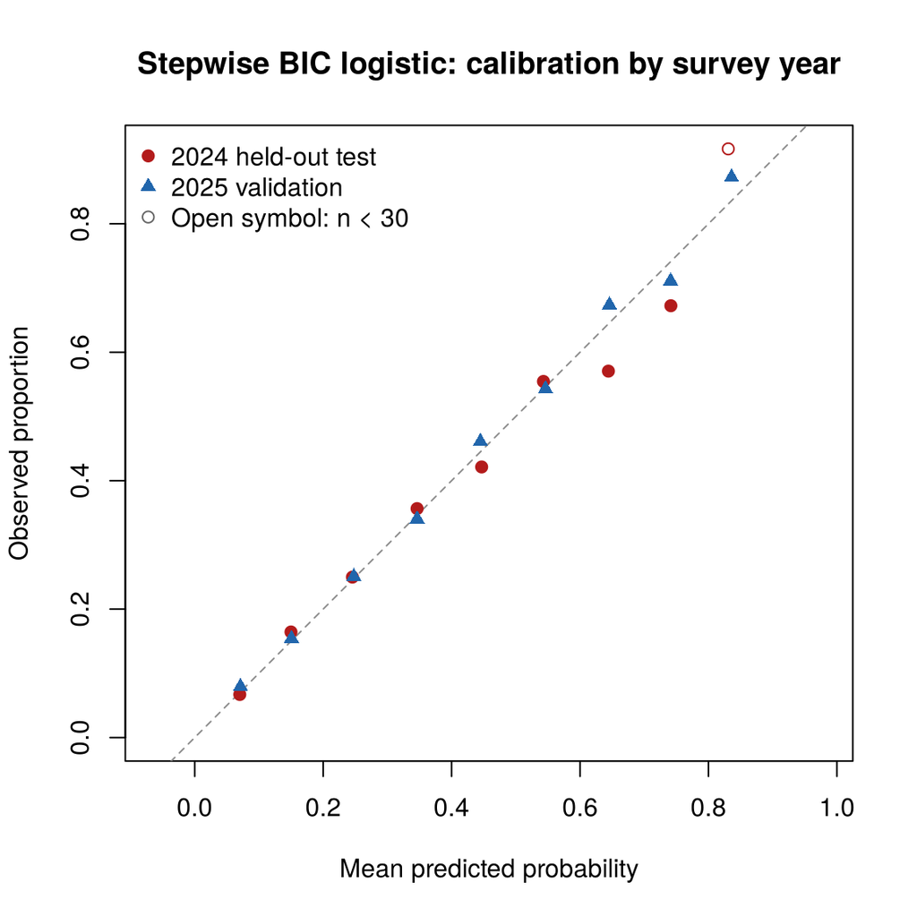

```r
axis_max <- max(0.7, cal_test$observed, cal_test$predicted,
                cal_2025$observed, cal_2025$predicted)
plot(NA_real_, NA_real_, xlim = c(0, axis_max), ylim = c(0, axis_max),
     asp = 1, xlab = "Mean predicted probability",
     ylab = "Observed proportion",
     main = paste0(primary_model, ": calibration by survey year"))
abline(0, 1, lty = 2, col = "gray55")
points(cal_test$predicted, cal_test$observed,
       pch = ifelse(cal_test$n < 30, 1, 19), col = "#B31B1B")
points(cal_2025$predicted, cal_2025$observed,
       pch = ifelse(cal_2025$n < 30, 2, 17), col = "#2166AC")
legend("topleft", bty = "n",
       legend = c("2024 held-out test", "2025 validation",
                  "Open symbol: n < 30"),
       pch = c(19, 17, 1), col = c("#B31B1B", "#2166AC", "gray40"))
```

## 5.5 Survey-weighted calibration in 2025

```r
weighted_cal_2025 <- calibration_by_band(prob_2025[[primary_model]], y_2025,
                                         weight_2025)
print(round(weighted_cal_2025, 4))
```

```
##              n weighted_share_pct predicted observed  gap_pp
## [0,0.1]   2802            13.5802    0.0703   0.0697 -0.0552
## (0.1,0.2] 6872            29.9210    0.1498   0.1541  0.4353
## (0.2,0.3] 5821            24.2462    0.2469   0.2546  0.7683
## (0.3,0.4] 3723            15.0488    0.3467   0.3464 -0.0313
## (0.4,0.5] 2181             8.7477    0.4447   0.4630  1.8342
## (0.5,0.6] 1282             4.9604    0.5459   0.5689  2.2950
## (0.6,0.7]  628             2.4173    0.6459   0.6789  3.2997
## (0.7,0.8]  249             0.8921    0.7418   0.7366 -0.5220
## (0.8,0.9]   47             0.1863    0.8347   0.7969 -3.7798
```

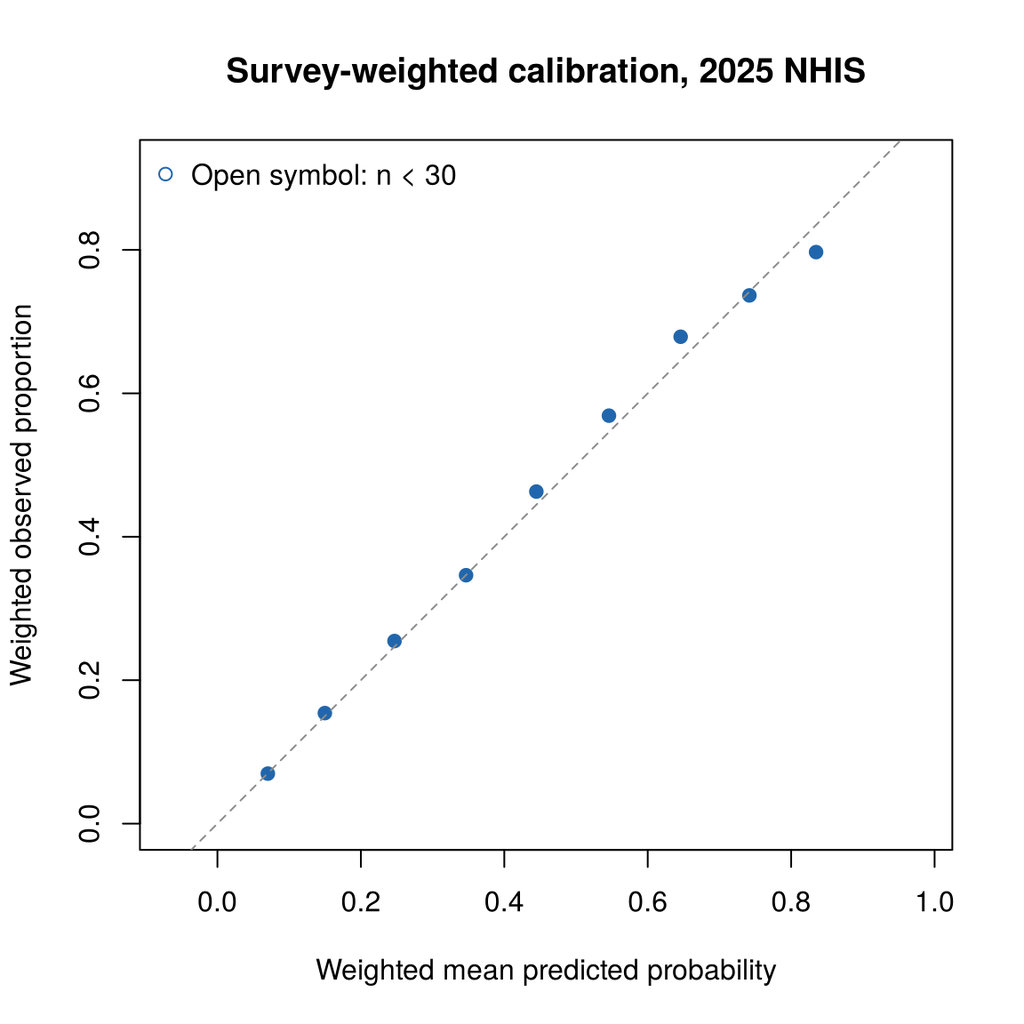

```r
plot(weighted_cal_2025$predicted, weighted_cal_2025$observed,
     xlim = c(0, axis_max), ylim = c(0, axis_max), asp = 1,
     pch = ifelse(weighted_cal_2025$n < 30, 1, 19), col = "#2166AC",
     xlab = "Weighted mean predicted probability",
     ylab = "Weighted observed proportion",
     main = "Survey-weighted calibration, 2025 NHIS")
abline(0, 1, lty = 2, col = "gray55")
legend("topleft", "Open symbol: n < 30", pch = 1, col = "#2166AC", bty = "n")
```

Design-based 95% CI for the weighted calibration gap (observed minus predicted, percentage points). The full survey design is built first and the validation sample is then treated as a domain.

```r
design_rows <- validation_2025$source_row
stopifnot(all(nhis_2025$WTFA_A[design_rows] == weight_2025))

nhis_2025$in_validation <- FALSE
nhis_2025$in_validation[design_rows] <- TRUE

weighted_gap <- function(model_name) {
  nhis_2025$gap_pp <- NA_real_
  nhis_2025$gap_pp[design_rows] <- 100 * (y_2025 - prob_2025[[model_name]])
  design <- svydesign(ids = ~PPSU, strata = ~PSTRAT, weights = ~WTFA_A,
                      data = nhis_2025, nest = TRUE)
  domain <- subset(design, in_validation)
  est <- svymean(~gap_pp, domain)
  ci <- confint(est, df = degf(domain))
  c(gap_pp = unname(coef(est)), lower_95 = ci[1, 1], upper_95 = ci[1, 2])
}

gap_table <- t(vapply(
  c("Theory-based logistic", "Theory-based BIC logistic", primary_model),
  weighted_gap, numeric(3)
))
print(round(gap_table, 3))
```

```
##                           gap_pp lower_95 upper_95
## Theory-based logistic      1.082    0.279    1.886
## Theory-based BIC logistic  1.207    0.406    2.009
## Stepwise BIC logistic      0.647   -0.151    1.444
```

```r
print(round(c(
  weighted_observed_pct = 100 * weighted.mean(y_2025, weight_2025),
  weighted_predicted_pct = 100 * weighted.mean(prob_2025[[primary_model]],
                                               weight_2025)
), 2))
```

```
##  weighted_observed_pct weighted_predicted_pct
##                  26.26                  25.62
```

# 6 Sensitivity: survey-weighted model fitting

The primary formula is refit with the NHIS adult weights (rescaled to mean 1; quasibinomial family, so point estimates equal weighted maximum likelihood). Variable selection is not repeated. Both versions are scored unweighted and weighted in the 2024 test set and in 2025.

```r
train_w <- train_data$survey_weight / mean(train_data$survey_weight)
fit_primary_weighted <- glm(f_bic, data = train_data, family = quasibinomial(),
                            weights = train_w)

score_versions <- function(data, y, w) {
  p_unw <- unname(predict(fit_primary, data, type = "response"))
  p_w <- unname(predict(fit_primary_weighted, data, type = "response"))
  rbind(
    "Unweighted fit, unweighted metrics" = evaluate_prob(p_unw, y)[c("log_loss", "AUROC", "Brier")],
    "Weighted fit, unweighted metrics" = evaluate_prob(p_w, y)[c("log_loss", "AUROC", "Brier")],
    "Unweighted fit, weighted metrics" = weighted_metrics(p_unw, y, w),
    "Weighted fit, weighted metrics" = weighted_metrics(p_w, y, w)
  )
}

cat("2024 test set\n")
```

```
## 2024 test set
```

```r
print(round(score_versions(test_data, y_test, weight_test), 4))
```

```
##                                    log_loss  AUROC  Brier
## Unweighted fit, unweighted metrics   0.5137 0.7128 0.1696
## Weighted fit, unweighted metrics     0.5149 0.7116 0.1701
## Unweighted fit, weighted metrics     0.5015 0.7155 0.1647
## Weighted fit, weighted metrics       0.5027 0.7140 0.1651
```

```r
cat("\n2025 validation\n")
```

```
##
## 2025 validation
```

```r
print(round(score_versions(validation_2025, y_2025, weight_2025), 4))
```

```
##                                    log_loss  AUROC  Brier
## Unweighted fit, unweighted metrics   0.5206 0.7173 0.1722
## Weighted fit, unweighted metrics     0.5214 0.7166 0.1725
## Unweighted fit, weighted metrics     0.5104 0.7251 0.1683
## Weighted fit, weighted metrics       0.5112 0.7242 0.1686
```

```r
cat("\nWeighted mean predicted vs observed in 2025 (percent):\n")
```

```
##
## Weighted mean predicted vs observed in 2025 (percent):
```

```r
print(round(100 * c(
  observed = weighted.mean(y_2025, weight_2025),
  unweighted_fit = weighted.mean(predict(fit_primary, validation_2025,
                                         type = "response"), weight_2025),
  weighted_fit = weighted.mean(predict(fit_primary_weighted, validation_2025,
                                       type = "response"), weight_2025)
), 2))
```

```
##       observed unweighted_fit   weighted_fit
##          26.26          25.62          25.60
```

# 7 Sensitivity: collinearity and interactions

## 7.1 Collinearity

Generalized variance inflation factors (Fox and Monette), computed from the correlation of the coefficient estimates as in `car::vif()`. For an item with df parameters, GVIF^(1/(2·df)) is comparable to the square root of a classic VIF; values above about 2.2 (VIF > 5) deserve attention.

```r
gvif_table <- function(fit) {
  R <- cov2cor(vcov(fit)[-1, -1])
  assign <- attr(model.matrix(fit), "assign")[-1]
  labels <- attr(terms(fit), "term.labels")
  det_R <- det(R)
  out <- t(vapply(seq_along(labels), function(j) {
    idx <- which(assign == j)
    g <- det(R[idx, idx, drop = FALSE]) * det(R[-idx, -idx, drop = FALSE]) / det_R
    c(df = length(idx), GVIF = g, GVIF_adjusted = g^(1 / (2 * length(idx))))
  }, numeric(3)))
  out <- data.frame(term = labels, round(out, 3))
  out[order(-out$GVIF_adjusted), ]
}

cat("Primary (stepwise BIC) model\n")
```

```
## Primary (stepwise BIC) model
```

```r
print(head(gvif_table(fit_primary), 10), row.names = FALSE)
```

```
##             term df   GVIF GVIF_adjusted
##       CEVOTELC_A  2 12.933         1.896
##       CEMMETNG_A  2 11.444         1.839
##          anxiety  1  1.719         1.311
##       depression  1  1.636         1.279
##      SOCWRKLIM_A  1  1.532         1.238
##          EQUIP_A  1  1.436         1.198
##        arthritis  1  1.408         1.187
##  ns(age, df = 3)  3  2.397         1.157
##          CHLEV_A  1  1.284         1.133
##        insurance  2  1.574         1.120
```

```r
cat("\nTheory-based (Andersen) model\n")
```

```
##
## Theory-based (Andersen) model
```

```r
print(head(gvif_table(fit_theory), 10), row.names = FALSE)
```

```
##                   term df   GVIF GVIF_adjusted
##       worked_last_week  2 22.424         2.176
##                us_born  2 22.330         2.174
##                marital  3 13.950         1.552
##                anxiety  1  1.614         1.270
##             depression  1  1.608         1.268
##        ns(age, df = 3)  3  2.856         1.191
##           hypertension  1  1.398         1.182
##              arthritis  1  1.393         1.180
##             disability  1  1.338         1.157
##  ns(pov_ratio, df = 3)  3  2.001         1.123
```

Several items with large raw GVIFs have a Missing/Unknown category. One possible explanation is that largely the same respondents (about 3%) are unascertained on several of these items; the cross-tabulation below checks how much these categories overlap. This is a diagnostic, not a proof of the source of the inflation.

```r
# Respondents in the Missing/Unknown category of at least one item, and of
# every item, in each group of items with high GVIF.
missing_overlap <- function(data, items, level) {
  flags <- vapply(items, function(v) data[[v]] == level, logical(nrow(data)))
  c(any_item = sum(rowSums(flags) > 0), all_items = sum(rowSums(flags) == length(items)))
}
print(rbind(
  "Primary: voted / public meeting (Missing)" =
    missing_overlap(train_data, c("CEVOTELC_A", "CEMMETNG_A"), "Missing"),
  "Theory-based: marital / U.S.-born / worked (Unknown)" =
    missing_overlap(train_data, c("marital", "us_born", "worked_last_week"), "Unknown")
))
```

```
##                                                      any_item all_items
## Primary: voted / public meeting (Missing)                 992       901
## Theory-based: marital / U.S.-born / worked (Unknown)      813       692
```

Pairwise association between the predictors of the primary model (Cramér’s V; continuous variables split into quartiles):

```r
as_categories <- function(x) {
  if (is.numeric(x)) cut(x, unique(quantile(x, 0:4 / 4)), include.lowest = TRUE) else x
}
cramers_v <- function(a, b) {
  tab <- table(as_categories(a), as_categories(b))
  chi2 <- suppressWarnings(chisq.test(tab, correct = FALSE)$statistic)
  unname(sqrt(chi2 / (sum(tab) * (min(dim(tab)) - 1))))
}

primary_vars <- all.vars(f_bic)[-1]
var_pairs <- t(combn(primary_vars, 2))
association <- data.frame(
  var1 = var_pairs[, 1], var2 = var_pairs[, 2],
  cramers_v = round(apply(var_pairs, 1, function(p) {
    cramers_v(train_data[[p[1]]], train_data[[p[2]]])
  }), 3)
)
print(head(association[order(-association$cramers_v), ], 12), row.names = FALSE)
```

```
##         var1        var2 cramers_v
##   CEVOTELC_A  CEMMETNG_A     0.686
##   depression     anxiety     0.590
##    ANXFREQ_A     anxiety     0.469
##       health SOCWRKLIM_A     0.443
##  SOCWRKLIM_A     EQUIP_A     0.417
##   depression   ANXFREQ_A     0.416
##          age   arthritis     0.407
##          age     CHLEV_A     0.386
##       health     EQUIP_A     0.369
##       cancer         age     0.327
##       health   arthritis     0.310
##    insurance   pov_ratio     0.305
```

## 7.2 Pairwise interactions

This analysis is exploratory. All pairwise interactions among the terms of each model are screened in one pass (change in BIC when each is added alone); those that lower BIC are then offered to a forward stepwise BIC search. Selection uses the full training set, and the resulting formula is then cross-validated, so the CV log loss is an *apparent* value that is not comparable with the nested estimates.

```r
select_interactions <- function(fit) {
  labels <- attr(terms(fit), "term.labels")
  candidates <- apply(t(combn(labels, 2)), 1, paste, collapse = ":")
  screen <- add1(fit, scope = reformulate(c(labels, candidates)),
                 k = log(n_train))[-1, ]
  base_bic <- extractAIC(fit, k = log(n_train))[2]
  screen <- data.frame(interaction = rownames(screen), df = screen$Df,
                       delta_BIC = screen$AIC - base_bic)
  screen <- screen[order(screen$delta_BIC), ]

  passed <- screen$interaction[screen$delta_BIC < 0]
  final_formula <- formula(fit)
  if (length(passed)) {
    upper <- update(formula(fit), paste(". ~ . +", paste(passed, collapse = " + ")))
    final_fit <- step(fit, scope = list(lower = formula(fit), upper = upper),
                      direction = "forward", k = log(n_train), trace = 0)
    final_formula <- formula(final_fit)
  }
  added <- setdiff(attr(terms(final_formula), "term.labels"), labels)
  list(screen = screen, n_candidates = length(candidates),
       added = added, formula = final_formula)
}

interactions <- list(
  "Stepwise BIC" = select_interactions(fit_primary),
  "Theory-based" = select_interactions(fit_theory)
)

for (m in names(interactions)) {
  x <- interactions[[m]]
  cat("\n", m, "model:", sum(x$screen$delta_BIC < 0), "of", x$n_candidates,
      "interactions lower BIC when added alone\n")
  shown <- head(x$screen, 10)
  shown$delta_BIC <- round(shown$delta_BIC, 1)
  print(shown, row.names = FALSE)
  cat("Entered by forward BIC:",
      if (length(x$added)) paste(x$added, collapse = ", ") else "none", "\n")
}
```

```
##
##  Stepwise BIC model: 19 of 253 interactions lower BIC when added alone
##                 interaction df delta_BIC
##     anxiety:ns(age, df = 3)  3     -32.1
##        depression:arthritis  1     -24.1
##  depression:ns(age, df = 3)  3     -19.7
##           anxiety:arthritis  1     -16.8
##          depression:EQUIP_A  1     -13.8
##             anxiety:CHLEV_A  1     -11.3
##             anxiety:EQUIP_A  1     -10.9
##           depression:cancer  1      -8.1
##         depression:PREDIB_A  1      -8.0
##          depression:CHLEV_A  1      -6.5
## Entered by forward BIC: anxiety:ns(age, df = 3), depression:arthritis, MILITARY_A:sex, depression:sex
##
##  Theory-based model: 21 of 231 interactions lower BIC when added alone
##                 interaction df delta_BIC
##     ns(age, df = 3):anxiety  3     -33.6
##        hypertension:anxiety  1     -32.8
##     hypertension:depression  1     -27.8
##            sex:hypertension  1     -27.5
##        arthritis:depression  1     -25.6
##  ns(age, df = 3):depression  3     -22.3
##        sex:worked_last_week  2     -17.3
##           arthritis:anxiety  1     -15.7
##              sex:depression  1     -11.5
##             copd:depression  1     -10.9
## Entered by forward BIC: ns(age, df = 3):anxiety, sex:hypertension, sex:depression, hypertension:depression
```

```r
base_formulas <- list("Stepwise BIC" = f_bic, "Theory-based" = f_theory)

interaction_results <- do.call(rbind, lapply(names(base_formulas), function(m) {
  do.call(rbind, lapply(c("Main effects", "With interactions"), function(version) {
    f <- if (version == "Main effects") base_formulas[[m]] else interactions[[m]]$formula
    fit <- glm(f, data = train_data, family = binomial())
    p_test <- predict(fit, test_data, type = "response")
    p_2025 <- predict(fit, validation_2025, type = "response")
    data.frame(
      model = m, version = version, n_parameters = length(coef(fit)),
      apparent_cv_logloss = round(mean(cv_logistic(f)), 5),
      test_logloss = round(log_loss(y_test, p_test), 4),
      test_AUROC = round(auroc(p_test, y_test), 4),
      logloss_2025 = round(log_loss(y_2025, p_2025), 4),
      AUROC_2025 = round(auroc(p_2025, y_2025), 4)
    )
  }))
}))
print(interaction_results, row.names = FALSE)
```

```
##         model           version n_parameters apparent_cv_logloss test_logloss test_AUROC logloss_2025
##  Stepwise BIC      Main effects           44             0.50750       0.5137     0.7128       0.5206
##  Stepwise BIC With interactions           50             0.50571       0.5126     0.7144       0.5195
##  Theory-based      Main effects           44             0.51422       0.5215     0.6974       0.5286
##  Theory-based With interactions           50             0.51191       0.5217     0.6976       0.5279
##  AUROC_2025
##      0.7173
##      0.7187
##      0.7039
##      0.7053
```

The primary model remains the main-effects model fixed before evaluation; the interaction results do not change it and are not used to choose between model structures.

# 8 Interpretation of the primary model

Odds ratios from the stepwise BIC model (unweighted, training set). They describe adjusted associations useful for prediction, are conditional on the selected model (post-selection intervals are too narrow), and are not causal effects or population estimates. The intervals ignore the survey design and the selection step, so they should not be used to call any predictor a significant risk factor. Category names come from the coding dictionary.

```r
coefs <- summary(fit_primary)$coefficients
keep <- !grepl("^\\(Intercept\\)|^ns\\(", rownames(coefs))
or_table <- data.frame(
  term = rownames(coefs)[keep],
  OR = exp(coefs[keep, "Estimate"]),
  lower_95 = exp(coefs[keep, "Estimate"] - 1.96 * coefs[keep, "Std. Error"]),
  upper_95 = exp(coefs[keep, "Estimate"] + 1.96 * coefs[keep, "Std. Error"])
)
or_table$item <- vapply(or_table$term, function(t) {
  hit <- names(variable_labels)[startsWith(t, names(variable_labels))]
  if (length(hit)) variable_labels[hit[which.max(nchar(hit))]] else ""
}, character(1))
print(or_table, row.names = FALSE, digits = 3)
```

```
##                                 term    OR lower_95 upper_95                                     item
##                        depressionYes 1.550    1.419    1.693
##    educationSome college / associate 0.756    0.699    0.818
##           educationHigh school / GED 0.605    0.553    0.661
##       educationLess than high school 0.533    0.460    0.619
##                       ANXFREQ_ADaily 1.632    1.456    1.829    Frequency of worried/anxious feelings
##                      ANXFREQ_AWeekly 1.501    1.351    1.667    Frequency of worried/anxious feelings
##                     ANXFREQ_AMonthly 1.325    1.187    1.478    Frequency of worried/anxious feelings
##          ANXFREQ_AA few times a year 1.145    1.051    1.247    Frequency of worried/anxious feelings
##                     ANXFREQ_AMissing 1.024    0.717    1.463    Frequency of worried/anxious feelings
##                        regionMidwest 0.822    0.743    0.910
##                          regionSouth 1.004    0.916    1.100
##                           regionWest 1.364    1.240    1.501
##                      healthVery good 1.211    1.105    1.327
##                           healthGood 1.421    1.289    1.567
##                           healthFair 1.684    1.486    1.908
##                           healthPoor 1.725    1.431    2.079
##           URBRRL23Large fringe metro 0.896    0.822    0.976 Urban-rural classification (2023 scheme)
##        URBRRL23Medium or small metro 0.706    0.652    0.765 Urban-rural classification (2023 scheme)
##              URBRRL23Nonmetropolitan 0.586    0.534    0.643 Urban-rural classification (2023 scheme)
##  insurancePublic / other, no private 1.076    0.994    1.166
##                   insuranceUninsured 0.537    0.457    0.630
##                        EVERCOVD_AYes 1.331    1.247    1.421                        Ever had COVID-19
##                           anxietyYes 1.517    1.384    1.663
##                         ACCSSHOM_ANo 0.583    0.509    0.667                Uses the Internet at home
##                        CEVOTELC_AYes 1.286    1.201    1.378             Voted in last local election
##                    CEVOTELC_AMissing 1.098    0.648    1.859             Voted in last local election
##                       SOCWRKLIM_AYes 1.306    1.197    1.424                          Work limitation
##                            cancerYes 1.379    1.261    1.508
##                        MILITARY_AYes 1.544    1.362    1.750                        Military coverage
##                            sexFemale 1.273    1.194    1.356
##                          PREDIB_AYes 1.216    1.122    1.316                         Ever prediabetes
##                            asthmaYes 1.221    1.125    1.325
##                         arthritisYes 1.170    1.082    1.266
##                           EQUIP_AYes 1.265    1.126    1.422                  Uses mobility equipment
##                           CHLEV_AYes 1.140    1.062    1.224                    Ever high cholesterol
##                        CEMMETNG_AYes 1.245    1.133    1.369                  Attended public meeting
##                    CEMMETNG_AMissing 1.052    0.609    1.815                  Attended public meeting
```

The curves below are *reference-profile* predictions: predicted probability for one hypothetical adult whose other predictors are fixed at the most common category (or the median). They show the shape of the spline terms; they are not population-average effects.

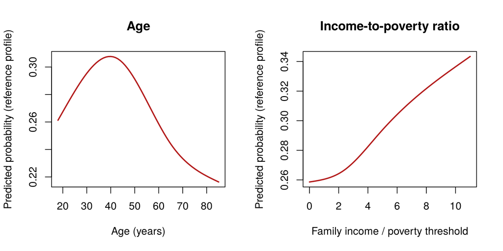

```r
model_vars <- all.vars(f_bic)[-1]
reference_profile <- train_data[1, model_vars]
for (v in model_vars) {
  x <- train_data[[v]]
  reference_profile[[v]] <- if (is.factor(x)) {
    factor(names(which.max(table(x))), levels = levels(x))
  } else median(x)
}

par(mfrow = c(1, 2))
if ("age" %in% model_vars) {
  age_grid <- reference_profile[rep(1, 68), ]
  age_grid$age <- 18:85
  plot(18:85, predict(fit_primary, age_grid, type = "response"), type = "l",
       lwd = 2, col = "#B31B1B", xlab = "Age (years)",
       ylab = "Predicted probability (reference profile)", main = "Age")
}
if ("pov_ratio" %in% model_vars) {
  pov_seq <- seq(0, 11, by = 0.1)
  pov_grid <- reference_profile[rep(1, length(pov_seq)), ]
  pov_grid$pov_ratio <- pov_seq
  plot(pov_seq, predict(fit_primary, pov_grid, type = "response"), type = "l",
       lwd = 2, col = "#B31B1B", xlab = "Family income / poverty threshold",
       ylab = "Predicted probability (reference profile)",
       main = "Income-to-poverty ratio")
}
```

```r
par(mfrow = c(1, 1))
```

```r
# Increase in mean CV log loss when each item is removed from the primary
# model.
base_loss <- mean(cv_logistic(f_bic))
drop_one <- vapply(bic_terms, function(t) {
  kept <- setdiff(bic_terms, t)
  mean(cv_logistic(reformulate(kept, response = "telehealth"))) - base_loss
}, numeric(1))
importance <- data.frame(
  term = names(drop_one),
  label = ifelse(names(drop_one) %in% names(variable_labels),
                 variable_labels[names(drop_one)], ""),
  cv_logloss_increase = round(drop_one, 5)
)
print(importance[order(-importance$cv_logloss_increase), ], row.names = FALSE)
```

```
##                   term                                    label cv_logloss_increase
##               URBRRL23 Urban-rural classification (2023 scheme)             0.00304
##              education                                                      0.00284
##                 region                                                      0.00242
##             depression                                                      0.00178
##              ANXFREQ_A    Frequency of worried/anxious feelings             0.00163
##                anxiety                                                      0.00141
##             EVERCOVD_A                        Ever had COVID-19             0.00140
##                 health                                                      0.00139
##              insurance                                                      0.00139
##             ACCSSHOM_A                Uses the Internet at home             0.00123
##                    sex                                                      0.00104
##        ns(age, df = 3)                                                      0.00102
##                 cancer                                                      0.00094
##             CEVOTELC_A             Voted in last local election             0.00092
##             MILITARY_A                        Military coverage             0.00089
##  ns(pov_ratio, df = 3)                                                      0.00071
##            SOCWRKLIM_A                          Work limitation             0.00070
##               PREDIB_A                         Ever prediabetes             0.00042
##                 asthma                                                      0.00033
##                EQUIP_A                  Uses mobility equipment             0.00027
##             CEMMETNG_A                  Attended public meeting             0.00026
##              arthritis                                                      0.00022
##                CHLEV_A                    Ever high cholesterol             0.00020
```

# 9 Model export

The fitted models are written to `model_export/` so that they can be reported in full (TRIPOD) and applied to new data without rerunning this document. The logistic and group lasso models are exported as coefficient tables, together with the spline knots and factor levels estimated from the 2024 training data; the XGBoost model is saved in xgboost’s JSON format. Full R model objects are not saved, because they contain a copy of the training data. The standalone scoring function below reads only the exported files; the last chunk checks that it reproduces the 2025 predictions of every exported model.

```r
export_dir <- "model_export"
dir.create(export_dir, showWarnings = FALSE)

# Coefficients. Column names follow R's model.matrix() naming: a factor
# level is the variable name followed by the level label, and a spline
# basis is the term followed by 1, 2, 3. The first level of each factor is
# the reference category.
logistic_fits <- list(
  "Theory-based logistic" = fit_theory,
  "Theory-based BIC logistic" = fit_theory_bic,
  "Stepwise BIC logistic" = fit_primary
)
logistic_coefficients <- do.call(rbind, lapply(names(logistic_fits), function(m) {
  fit <- logistic_fits[[m]]
  stopifnot(!anyNA(coef(fit)))
  assign_ <- attr(model.matrix(fit), "assign")
  data.frame(
    model = m,
    term = c("(Intercept)", attr(terms(fit), "term.labels"))[assign_ + 1],
    column = names(coef(fit)),
    estimate = unname(coef(fit)),
    std_error = unname(sqrt(diag(vcov(fit))))
  )
}))

# Group lasso: penalized estimates on the original scale, nonzero groups
# only. No standard errors are defined for these estimates.
glasso_coefficients <- do.call(rbind, lapply(
  list("Group lasso (lambda.min)" = i_min, "Group lasso (lambda.1se)" = i_1se),
  function(i) {
    b <- coef(cv_glasso$fit, lambda = cv_glasso$lambda[i])
    stopifnot(identical(names(b)[-1], colnames(x_train)))
    keep <- c(TRUE, b[-1] != 0)
    data.frame(
      term = c("(Intercept)", term_of_column)[keep],
      column = names(b)[keep],
      estimate = unname(b[keep]),
      std_error = NA_real_
    )
  }))
glasso_coefficients$model <- sub("\\.[0-9]+$", "", rownames(glasso_coefficients))
glasso_coefficients <- glasso_coefficients[, names(logistic_coefficients)]

model_coefficients <- rbind(logistic_coefficients, glasso_coefficients)
rownames(model_coefficients) <- NULL
write.csv(model_coefficients, file.path(export_dir, "model_coefficients.csv"),
          row.names = FALSE)

# Spline knots (quantiles of the 2024 training data). All models were fit to
# the same rows, so they share one set of knots.
spline_knots <- function(fit) {
  calls <- as.list(attr(terms(fit), "predvars"))[-1]
  do.call(rbind, lapply(calls, function(e) {
    if (!is.call(e) || !deparse(e[[1]]) %in% c("ns", "splines::ns")) return(NULL)
    v <- deparse(e[[2]])
    rbind(data.frame(variable = v, type = "interior", value = unname(eval(e$knots))),
          data.frame(variable = v, type = "boundary",
                     value = unname(eval(e$Boundary.knots))))
  }))
}
knots_table <- spline_knots(fit_theory)
sort_knots <- function(k) k[order(k$variable, k$type, k$value), "value"]
for (fit in logistic_fits) {
  k <- spline_knots(fit)
  stopifnot(identical(sort_knots(k),
                      sort_knots(knots_table[knots_table$variable %in% k$variable, ])))
}
write.csv(knots_table, file.path(export_dir, "spline_knots.csv"), row.names = FALSE)
print(knots_table, row.names = FALSE)
```

```
##   variable     type     value
##        age interior 43.000000
##        age interior 65.000000
##        age boundary 18.000000
##        age boundary 85.000000
##  pov_ratio interior  2.330000
##  pov_ratio interior  4.783333
##  pov_ratio boundary  0.000000
##  pov_ratio boundary 11.000000
```

```r
# Factor levels, in model order (the first level is the reference).
model_vars_all <- unique(sub("^ns\\(([^,]+),.*$", "\\1",
                             setdiff(model_coefficients$term, "(Intercept)")))
factor_vars <- model_vars_all[vapply(model_vars_all,
                                     function(v) is.factor(train_data[[v]]),
                                     logical(1))]
for (m in names(logistic_fits)) {
  xl <- logistic_fits[[m]]$xlevels
  for (v in names(xl)) stopifnot(identical(xl[[v]], levels(train_data[[v]])))
}
factor_levels <- do.call(rbind, lapply(factor_vars, function(v) {
  lev <- levels(train_data[[v]])
  data.frame(variable = v, level_order = seq_along(lev), level = lev,
             reference = seq_along(lev) == 1)
}))
write.csv(factor_levels, file.path(export_dir, "factor_levels.csv"), row.names = FALSE)

# XGBoost: model file, input columns and tuning result.
invisible(xgb.save(xgb_pool_fit, file.path(export_dir, "xgb_full_pool.json")))
write.csv(data.frame(feature = colnames(xgb_matrix(train_data, pool_vars))),
          file.path(export_dir, "xgb_features.csv"), row.names = FALSE)
write.csv(data.frame(setting = c(names(xgb_pool$params), "nrounds"),
                     value = c(vapply(xgb_pool$params, as.character, ""),
                               as.character(xgb_pool$nrounds))),
          file.path(export_dir, "xgb_settings.csv"), row.names = FALSE)

# Coding rules needed to prepare the raw NHIS items.
invisible(file.copy("coding_dictionary.csv", export_dir, overwrite = TRUE))

cat("Exported columns per model:\n")
```

```
## Exported columns per model:
```

```r
print(table(model_coefficients$model))
```

```
##
##  Group lasso (lambda.1se)  Group lasso (lambda.min)     Stepwise BIC logistic Theory-based BIC logistic
##                       111                       168                        44                        33
##     Theory-based logistic
##                        44
```

The scoring function is written to `model_export/predict_from_csv.R`. It expects data in which the model variables are already coded as in this analysis (coding dictionary; age in years; income-to-poverty ratio capped at 11).

```r
# Predicted probability of past-year telehealth use from the exported
# coefficient tables (HINF 5001, Team 1 prediction models).
#
# data:  one row per respondent. Every variable the model uses must already
#        be coded as in the analysis (see coding_dictionary.csv): age in
#        years; pov_ratio capped at 11; categorical variables as character
#        or factor using the labels in factor_levels.csv.
# model: a model name in model_coefficients.csv, for example
#        "Stepwise BIC logistic".
predict_from_csv <- function(data, model, export_dir = "model_export") {
  read <- function(f) read.csv(file.path(export_dir, f), stringsAsFactors = FALSE)
  coefs <- read("model_coefficients.csv")
  coefs <- coefs[coefs$model == model, ]
  if (nrow(coefs) == 0) stop("Unknown model: ", model)
  factor_levels <- read("factor_levels.csv")
  factor_levels <- factor_levels[order(factor_levels$variable,
                                       factor_levels$level_order), ]
  knots <- read("spline_knots.csv")

  columns <- list()
  for (term in setdiff(unique(coefs$term), "(Intercept)")) {
    if (startsWith(term, "ns(")) {
      v <- sub("^ns\\(([^,]+),.*$", "\\1", term)
      k <- knots[knots$variable == v, ]
      basis <- splines::ns(data[[v]],
                           knots = k$value[k$type == "interior"],
                           Boundary.knots = k$value[k$type == "boundary"])
      for (j in seq_len(ncol(basis))) columns[[paste0(term, j)]] <- basis[, j]
    } else if (term %in% factor_levels$variable) {
      lev <- factor_levels$level[factor_levels$variable == term]
      x <- as.character(data[[term]])
      unknown <- setdiff(unique(x[!is.na(x)]), lev)
      if (length(unknown)) {
        stop("Unknown level(s) of ", term, ": ", paste(unknown, collapse = ", "))
      }
      for (l in lev[-1]) columns[[paste0(term, l)]] <- as.numeric(x == l)
    } else {
      columns[[term]] <- as.numeric(data[[term]])
    }
  }
  x <- do.call(cbind, columns)

  beta <- setNames(coefs$estimate, coefs$column)
  slope <- beta[names(beta) != "(Intercept)"]
  absent <- setdiff(names(slope), colnames(x))
  if (length(absent)) stop("Columns not built: ", paste(absent, collapse = ", "))
  eta <- beta[["(Intercept)"]] + drop(x[, names(slope), drop = FALSE] %*% slope)
  plogis(eta)
}
```

A short README is written alongside the files.

```markdown
# Exported prediction models: past-year telehealth use (NHIS)

Models developed on the NHIS 2024 adult file (80% training split, seed 2026)
and temporally validated on the NHIS 2025 adult file. Generated by
`nhis_telehealth_prediction_final.Rmd`; see that document for methods.

| File | Contents |
|---|---|
| `model_coefficients.csv` | Intercept and coefficients (log-odds scale) of the theory-based, theory-based BIC and primary (stepwise BIC) logistic models, with standard errors; nonzero penalized coefficients of the two group lasso models (no standard errors) |
| `spline_knots.csv` | Interior and boundary knots of the natural splines `ns(age, df = 3)` and `ns(pov_ratio, df = 3)` (2024 training data) |
| `factor_levels.csv` | Levels of each categorical variable; the first level is the reference |
| `coding_dictionary.csv` | Rules that turn raw NHIS codes into the model variables, including nonresponse and skip handling |
| `predict_from_csv.R` | `predict_from_csv(data, model)`: predicted probabilities from the files above |
| `xgb_full_pool.json`, `xgb_features.csv`, `xgb_settings.csv` | XGBoost model (xgboost JSON format), its input columns (R `model.matrix` dummy coding) and tuning settings |

Input data must be coded as in the analysis: age in years, income-to-poverty
ratio capped at 11, categorical variables labelled as in `factor_levels.csv`.
Models were fit without survey weights. Predictions describe the NHIS adult
population of 2024–2025 and have not been validated outside this survey.
Raw NHIS files are not included; they are available from the National
Center for Health Statistics.
```

```r
# Reproduce the 2025 predictions from the exported files alone.
scorer <- new.env()
sys.source(file.path(export_dir, "predict_from_csv.R"), envir = scorer)
export_check <- data.frame(model = unique(model_coefficients$model))
export_check$max_abs_difference <- vapply(export_check$model, function(m) {
  max(abs(scorer$predict_from_csv(validation_2025, m, export_dir) - prob_2025[[m]]))
}, numeric(1))

xgb_reloaded <- xgb.load(file.path(export_dir, "xgb_full_pool.json"))
export_check <- rbind(export_check, data.frame(
  model = "Full pool XGBoost",
  max_abs_difference = max(abs(
    predict(xgb_reloaded, xgb.DMatrix(xgb_matrix(validation_2025, pool_vars))) -
      prob_2025[["Full pool XGBoost"]]))
))
print(export_check, row.names = FALSE)
```

```
##                      model max_abs_difference
##      Theory-based logistic       6.661338e-16
##  Theory-based BIC logistic       1.443290e-15
##      Stepwise BIC logistic       1.887379e-15
##   Group lasso (lambda.min)       1.110223e-15
##   Group lasso (lambda.1se)       1.276756e-15
##          Full pool XGBoost       0.000000e+00
```

```r
stopifnot(export_check$max_abs_difference < 1e-6)
list.files(export_dir)
```

```
## [1] "README.md"              "coding_dictionary.csv"  "factor_levels.csv"      "model_coefficients.csv"
## [5] "predict_from_csv.R"     "spline_knots.csv"       "xgb_features.csv"       "xgb_full_pool.json"
## [9] "xgb_settings.csv"
```

# 10 Limitations

- **Prior viewing of evaluation data.** In the current pipeline, development uses only 2024 training data and the list of 2025 variable names. Earlier iterations of this project, however, examined results in both the 2024 test set and the 2025 file (including before the decision to expand the predictor set), and the coding dictionary was drafted while viewing predictor distributions in the full 2024 file. Neither evaluation set should therefore be described as untouched or fully independent; the 2025 analysis is a temporal validation by the development team.
- **Scope of the validation.** The 2025 file tests transportability to the next year of the same survey and questionnaire, not to other populations or data sources.
- **What nested CV covers.** Nested CV repeats variable selection and model fitting inside folds, but not screening, coding or the outcome-proxy diagnostic (which uses training outcomes), and the inner CV of group lasso shares the spline basis of the outer training part. XGBoost tuning was not nested; its tuning scores are reported separately. Interaction and borderline-item analyses select on the full training set and report apparent CV values.
- **Uncertainty intervals.** Bootstrap intervals resample PSUs within strata for unweighted metrics of fixed models; they exclude uncertainty from training and selection and are not design-based intervals for weighted metrics.
- **Weights and missing data.** Models are fit unweighted; weighted metrics and a weighted refit are reported. Weighted results represent the complete-case population; the original weights do not correct for exclusion of respondents with missing predictors.
- **Coding and item classification.** The coding dictionary was checked against the 2024 and 2025 codebooks; the check should still be spot-checked by the team. Nonresponse is assigned to the most common category for items with little nonresponse, which can misclassify a small number of respondents. Excluding items whose answer a telehealth visit can produce is a judgment about question content; the outcome-proxy diagnostic can flag suspicious items but cannot prove that an unflagged item is free of leakage. Care-use and access items that passed the diagnostic are examined only in a sensitivity analysis.
- **Theory-based specification.** The 22 theory-based items are one operationalization of Andersen’s model, not a standard variable set, and cover individual predisposing, enabling and need factors plus urban-rural classification, but not other contextual factors or health behaviors. Urban-rural classification was added after earlier analyses had shown it to be a strong predictor, so the theory-based set is not fully specified independently of the data.
- **Income and year-specific coding.** The income-to-poverty ratio is based on the first of 10 income imputations and is top-coded at 11 in 2024 and 12 in 2025; it is capped at 11 for both years.
- **Selection stability.** Some selected items are not reselected in every fold or half-sample (see the stability tables); the primary model should be read as one good parsimonious model, not the unique correct one.
- **Post-selection inference.** Odds ratios and their intervals are conditional on the selected model, ignore the survey design, and describe associations, not causal effects.
- **Software environment.** Package versions are printed but not locked; other versions (notably of xgboost) may give slightly different results.

# 11 Summary

- Item pool: 629 items in the 2024 file, 425 of them also fielded in 2025; 89 candidate terms after screening (including the 22 theory-based terms); excluded by the outcome-proxy diagnostic: HITTEST_A, RX12M_A, HITLOOK_A, LASTDR_A.
- Primary model (stepwise BIC from the intercept-only model): 23 terms. Stepwise BIC within the theory-based items kept 17 of 22 terms.
- CV log loss (nested for selection procedures; XGBoost tuning score not ranked): theory-based all items 0.5142, theory-based BIC 0.5145, primary 0.5092, group lasso 0.5051.
- AUROC, 2024 test: theory-based 0.697, theory-based BIC 0.698, primary 0.713.
- AUROC, 2025: theory-based 0.704, theory-based BIC 0.704, primary 0.717.
- 2025 survey-weighted calibration gap (observed − predicted) for the primary model: 0.65 percentage points (95% CI -0.15 to 1.44).
- Exploratory interactions entering the primary model by forward BIC: anxiety:ns(age, df = 3), depression:arthritis, MILITARY_A:sex, depression:sex; 2025 AUROC 0.7173 without vs 0.7187 with interactions.